# MDL Mixture & Agent-side MDL-Regret over Gridworld Environments (Mixture-of-Experts)

This notebook computes, for multiple gridworld environments and RL agents:

- **MDL mixture performance** over a finite library of agents.
- **MDL Returns Regret** (difference between MDL mixture and each agent's performance).
- **MDL Regret**, an information-theoretic measure of excess bits per step.
- Plots **MDL Returns Regret vs environment complexity** and **MDL Regret vs environment complexity**.

Compared to the zlib-based versions, this notebook uses a **mixture-of-experts compressor** as a finite analogue of the **Solomonoff mixture over agents**:

- Each agent (or a predictor of its policy) is treated as an **expert** that outputs probabilities over actions.
- Experts are assigned **MDL-based prior weights** $( w_k \propto 2^{-|p_k|} )$.
- We run an **online Bayesian update** over experts while reading a combined stream of all agents' trajectories in a given environment.
- For each step belonging to agent A, we record:
  - bits used by agent A alone on that step, and
  - bits used by the mixture-of-experts on that step.

The difference (agent bits − mixture bits) is the **Agent-side MDL-Regret** for that agent in that environment, measured per step.

## Expected log file format

For each `(agent, env)` pair you should have a CSV file named:

Examples:

- `sarsa_4x4_trajectory.csv`
- `sarsa_10x4_trajectory.csv`
- `sarsa_16x16_trajectory.csv`

Each file must contain the columns:

- `episode`: episode index (int)
- `t`: time step within the episode (int)
- `obs`: state / observation (e.g. a string like `"(0, 3)"`)
- `act`: action (int)
- `rew`: reward (float)

The notebook derives a `done` flag automatically as the last row of each episode.

Here’s the updated notebook integrating the **mixture-of-experts compressor** as the Solomonoff-style baseline:

You just need to:

```python
import ast
import os
import math
from collections import defaultdict

import time
import random
from tqdm import tqdm

import numpy as np
import pandas as pd
import matplotlib.pyplot as plt
import matplotlib as mpl
import matplotlib.cm as cm

from typing import Dict, Any, Tuple

from tqdm import tqdm

from print_utils import set_print_output_file, get_print_func
# oprint = print
# print = get_print_func()
# printOutFile = None

from MetaAgent2NIGSelfSup import MetaAgent2NIGSelfSup as MetaAgent

from GridWorldCanonicalBenchmarkSuite import build_canonical_suite
```

```python
def doSeed(seed=None, verbose=True):
    if seed is None:
        seed = int(time.time()*1000) % (2**32)

    if verbose: print(seed)
    np.random.seed(seed)
    random.seed(seed)

    return seed

import importlib
import MetaAgent2NIGSelfSup
importlib.reload(MetaAgent2NIGSelfSup)
from MetaAgent2NIGSelfSup import MetaAgent2NIGSelfSup as MetaAgent
```

```python
import GridWorldCanonicalBenchmarkSuite
importlib.reload(GridWorldCanonicalBenchmarkSuite)

wall_reward_like_cliff = True

seed = None
# seed = 2345467781
seed = doSeed(seed)

random_maze_only = True # False #
lambda_cliff = 100.0

all_sizes = [(10, 5), (20, 10), (40, 20), (60,30), (80, 40), (100, 50)]

sizes = [(10, 5), (20, 10), (40, 20), (60,30), (80, 40), (100, 50)]
sizes = [(20, 10), (40, 20), (60,30), (80, 40), (100, 50)]
sizes = [(40, 20), (60,30), (80, 40), (100, 50)]
sizes = [(60,30), (80, 40), (100, 50)]
sizes = [(80, 40), (100, 50)]
sizes = [(100, 50)]
# sizes = [(10, 5)]
sizes = [(20, 10)]
# sizes = [(40, 20)]
# sizes = [(60,30)]
# sizes = [(80, 40)]
# sizes = [(100, 50)]

random_maze_str = f'_rmaze{lambda_cliff:.1f}'

num_percs = 20
perc0 = 0.0
percN = 1.0

show_full_grid_trajs_trace = False

suite = build_canonical_suite(sizes, random_maze_only=random_maze_only, lambda_cliff=lambda_cliff, seed=123,
                              num_percs=num_percs, perc0=perc0, percN=percN)


envs_eps = [ (env, n_episodes) for (fam, env_name, i), (env, n_episodes) in suite.items() ]

envs, num_episodes_list = zip(*envs_eps)
envs_dic = { env.name: env for env in envs }

envs = list(envs_dic.keys())
print(envs)

N = len(envs)//len(sizes)

print(f'N={N}')
```

```
3652927320
0 10000 Random
1928578606
1 10000 Random
1928578606
2 10000 Random
1928578606
3 10000 Random
1928578606
4 10000 Random
1928578606
5 10000 Random
1928578606
6 10000 Random
1928578606
7 10000 Random
1928578606
8 10000 Random
1928578606
9 10000 Random
1928578606
10 10000 Random
1928578606
11 10000 Random
1928578606
12 10000 Random
1928578606
13 10000 Random
1928578606
14 10000 Random
1928578606
15 10000 Random
1928578606
16 10000 Random
1928578606
17 10000 Random
1928578606
18 10000 Random
1928578606
19 10000 Random
1928578606
['Random-Maze-0.05-20x10', 'Random-Maze-0.1-20x10', 'Random-Maze-0.15-20x10', 'Random-Maze-0.2-20x10', 'Random-Maze-0.25-20x10', 'Random-Maze-0.3-20x10', 'Random-Maze-0.35-20x10', 'Random-Maze-0.4-20x10', 'Random-Maze-0.45-20x10', 'Random-Maze-0.5-20x10', 'Random-Maze-0.55-20x10', 'Random-Maze-0.6-2…
N=20
```

```python
# -----------------------
# CONFIG
# -----------------------

use_multiple_trajectories = False # True
use_trajectories_learned_from_Q_table = True
use_learned_trajectories = False # or use_trajectories_learned_from_Q_table
force_successfull_trajectories = True
force_small_trajectories = False # True
extract_trajectories_from_start_only = True

num_trajectories = 100

temperature_to_build_stochastic_policy = 0.3
value_mixture_action_temperature = 0.3 # 1.0 # 2.0 # 1.5 # 1.0 # 0.3
normalize_q_values_in_value_mixture = True # False


force_stochastic_action_probability = True # False #


update_posterior_when_building_trajectories = False # To set to True requires creating a new instance of meta-agent for each mode

calc_policies_from_Q_table = True
use_q_table_from_many_runs = False

multiple_starts_perc = 0.2

default_state_len = 2
save_full_state_info = True

all_modes = ["thompson", "value-mixture"]

alpha = 0.1 # 0.5

DIR_SUFFIX = ''
# DIR_SUFFIX = '-q'

# Directory where your *_trajectory.csv files live
DATA_DIR = "./logs"  # change as needed
# DATA_DIR = f"./logs_{num_trajectories}_tau{temperature_to_build_stochastic_policy}{DIR_SUFFIX}"  # change as needed




use_greedy_policy_to_build_trajectories_from_saved_Q_table = True # False #



use_median_to_calc_mdl_bits_per_step = False # results distinct from mean but with weird variance...

use_median_of_means_to_calc_mdl_bits_per_step = False and use_median_to_calc_mdl_bits_per_step # results like default mean

alpha_str = f'alpha{alpha}'
from_start_str = 'fs' if extract_trajectories_from_start_only else ''
multiple_starts_perc_str = f'{multiple_starts_perc:.2f}' if multiple_starts_perc > 0 else ''

TRAJ_DIR = DATA_DIR + "/traj_self_superv"

# TRAJ_DIR += multiple_starts_perc_str + from_start_str + alpha_str + henv_str

qtable_sub_dir = "/qtable_self_superv"

TRAJ_DIR += random_maze_str + f"-N={N}"
qtable_sub_dir += random_maze_str + f"-N={N}"

agent_name = 'qlearning'

QTABLE_DIR = DATA_DIR + qtable_sub_dir

if not os.path.exists(QTABLE_DIR):
    os.makedirs(QTABLE_DIR)

# QTABLE_DIR += multiple_starts_perc_str + alpha_str + henv_str

print(f'DATA_DIR exists={os.path.exists(DATA_DIR)}\n', DATA_DIR)

num_actions = 4

# Example: adjust to your real agents / envs
agents = [agent_name]

print(envs_dic.keys())
```

```
DATA_DIR exists=True
 ./logs
dict_keys(['Random-Maze-0.05-20x10', 'Random-Maze-0.1-20x10', 'Random-Maze-0.15-20x10', 'Random-Maze-0.2-20x10', 'Random-Maze-0.25-20x10', 'Random-Maze-0.3-20x10', 'Random-Maze-0.35-20x10', 'Random-Maze-0.4-20x10', 'Random-Maze-0.45-20x10', 'Random-Maze-0.5-20x10', 'Random-Maze-0.55-20x10', 'Random-…
```

```python
print(TRAJ_DIR)
print(QTABLE_DIR)
```

```
./logs/traj_self_superv_rmaze100.0-N=20
./logs/qtable_self_superv_rmaze100.0-N=20
```

```python
plot_markers = [
# '.', # Point marker
# ',', # Pixel marker
'o', # Circle marker
's', # Square marker
'^', # Triangle up marker
'p', # Pentagon marker
'D', # Diamond marker
'v', # Triangle down marker
'*', # Star marker
'<', # Triangle left marker
'>', # Triangle right marker
'x', # X marker
'+', # Plus marker
'P', # Plus (filled) marker
'h', # Hexagon 1 marker
'H', # Hexagon 2 marker
'X', # X (filled) marker
'd', # Thin diamond marker
'1', # tri_down
'2', # tri_up
'3', # tri_left
'4', # tri_right
]
```

```python
# -----------------------------
# Helpers: parameter counting
# -----------------------------

def count_params_tabular(num_states: int, num_actions: int) -> int:
    """
    Tabular Q-like policy: one parameter per (state, action).
    """
    return int(num_states) * int(num_actions)


def count_params_mlp(input_dim: int, hidden_layers, output_dim: int) -> int:
    """
    Count parameters for a simple fully-connected MLP:
      [input_dim] -> h1 -> h2 -> ... -> [output_dim]
    with biases at each layer.
    hidden_layers can be: int or list/tuple of ints.
    """
    if isinstance(hidden_layers, int):
        hidden_layers = [hidden_layers]
    else:
        hidden_layers = list(hidden_layers)

    dims = [input_dim] + hidden_layers + [output_dim]
    total = 0
    for d_in, d_out in zip(dims[:-1], dims[1:]):
        total += d_in * d_out   # weights
        total += d_out          # biases
    return total


# -----------------------------
# Encoding schemes (light)
# -----------------------------

def encode_choice(value: str, choices) -> int:
    """
    Return bits needed to encode a categorical choice.
    If value not in choices, we still allocate ceil(log2(len(choices)+1)).
    """
    n = len(choices)
    if n <= 1:
        return 0
    return math.ceil(math.log2(n))


def encode_numeric_bucket(value: float, buckets) -> int:
    """
    Encode a numeric hyperparameter by snapping it to a finite set of buckets.
    Cost = ceil(log2(#buckets)).
    `value` is ignored for bit count (we just assume it's in one of the buckets).
    """
    n = len(buckets)
    if n <= 1:
        return 0
    return math.ceil(math.log2(n))


def encode_integer_range(value: int, max_value: int) -> int:
    """
    Encode an integer hyperparameter up to some max_value.
    Cost = ceil(log2(max_value)).
    """
    max_value = max(1, int(max_value))
    return math.ceil(math.log2(max_value))


# -----------------------------
# Main MDL calculator
# -----------------------------

def compute_agent_description_length(meta: Dict[str, Any]) -> Tuple[float, Dict[str, float]]:
    """
    Compute a 'light' MDL-style description length for an RL agent,
    based only on:
      - algorithm family
      - model architecture
      - coarse hyperparameters

    Expected keys in `meta` (you can add more if you like):

      Required:
        - algo: str                # e.g. "sarsa", "qlearning", "dqn"
        - model_type: str          # "tabular" or "mlp"

      If model_type == "tabular":
        - num_states: int
        - num_actions: int

      If model_type == "mlp":
        - input_dim: int
        - hidden_layers: int or list[int]
        - output_dim: int

      Optional hyperparams (used if present):
        - gamma: float
        - alpha: float
        - epsilon_schedule: str       # "fixed"|"linear"|"exp"|...
        - episodes: int
        - optimizer: str              # "sgd"|"adam"|...
        - replay: bool
        - target_network: bool
        - bootstrapping_n: int

    Returns:
      total_bits: float
      breakdown: dict[str, float]
    """

    algo = meta.get("algo", "unknown")
    model_type = meta.get("model_type", "tabular")

    breakdown: Dict[str, float] = {}

    # -----------------------------
    # 1) Encode algorithm family
    # -----------------------------
    known_algos = ["monte_carlo","dynamic_programming", "qlearning", "sarsa", "reinforce", "actor_critic", "dyna_q",
                   "double_q", "dqn", "ddqn", "ppo", "a2c"]
    bits_algo = encode_choice(algo, known_algos)
    breakdown["algo_bits"] = bits_algo

    # -----------------------------
    # 2) Encode model architecture
    # -----------------------------
    model_types = ["tabular", "mlp"]
    bits_model_type = encode_choice(model_type, model_types)

    # Parameter count
    if model_type == "tabular":
        ns = meta["num_states"]
        na = meta["num_actions"]
        num_params = count_params_tabular(ns, na)

        # encode ns and na roughly
        bits_ns = encode_integer_range(ns, max_value=10_000)   # assume <= 10k states
        bits_na = encode_integer_range(na, max_value=100)      # assume <= 100 actions
        bits_arch_detail = bits_ns + bits_na

    elif model_type == "mlp":
        input_dim = meta["input_dim"]
        hidden_layers = meta["hidden_layers"]
        output_dim = meta["output_dim"]
        num_params = count_params_mlp(input_dim, hidden_layers, output_dim)

        # encode dims coarsely: each dim <= 10k
        bits_input_dim = encode_integer_range(input_dim, max_value=10_000)
        if isinstance(hidden_layers, int):
            h_list = [hidden_layers]
        else:
            h_list = list(hidden_layers)
        bits_hidden_dims = sum(encode_integer_range(h, max_value=10_000) for h in h_list)
        bits_output_dim = encode_integer_range(output_dim, max_value=10_000)

        bits_arch_detail = bits_input_dim + bits_hidden_dims + bits_output_dim

    else:
        # If unknown model type, assume some generic overhead
        num_params = meta.get("num_params", 0)
        bits_arch_detail = 8  # arbitrary fallback

    # Structural MDL trick: encode size as log2(#params) bits
    bits_num_params = math.log2(num_params) if num_params > 0 else 0.0

    breakdown["model_type_bits"] = bits_model_type
    breakdown["arch_detail_bits"] = bits_arch_detail
    breakdown["param_count_bits"] = bits_num_params

    # -----------------------------
    # 3) Encode hyperparameters (coarse buckets)
    # -----------------------------
    bits_hyper = 0.0

    # gamma bucket
    if "gamma" in meta:
        # typical bucket set for gamma
        gamma_buckets = [0.90, 0.95, 0.99, 0.995]
        bits_gamma = encode_numeric_bucket(meta["gamma"], gamma_buckets)
        breakdown["gamma_bits"] = bits_gamma
        bits_hyper += bits_gamma

    # alpha (learning rate) bucket
    if "alpha" in meta:
        alpha_buckets = [1e-1, 5e-2, 1e-2, 5e-3, 1e-3]
        bits_alpha = encode_numeric_bucket(meta["alpha"], alpha_buckets)
        breakdown["alpha_bits"] = bits_alpha
        bits_hyper += bits_alpha

    # epsilon schedule
    if "epsilon_schedule" in meta:
        eps_choices = ["fixed", "linear", "exp", "polynomial"]
        bits_eps = encode_choice(meta["epsilon_schedule"], eps_choices)
        breakdown["epsilon_schedule_bits"] = bits_eps
        bits_hyper += bits_eps

    # optimizer (mostly for NN agents)
    if "optimizer" in meta:
        opt_choices = ["none", "sgd", "adam", "rmsprop", "adagrad"]
        bits_opt = encode_choice(meta["optimizer"], opt_choices)
        breakdown["optimizer_bits"] = bits_opt
        bits_hyper += bits_opt

    # episodes (training horizon, coarse buckets)
    if "episodes" in meta:
        # Assume episodes in [1, 1e6], encode as log2 bucket up to 1e6
        bits_episodes = encode_integer_range(meta["episodes"], max_value=1_000_000)
        breakdown["episodes_bits"] = bits_episodes
        bits_hyper += bits_episodes

    # replay buffer usage
    if "replay" in meta:
        # size of the replay buffer (s, a)*n
        bits_replay = encode_integer_range(meta["replay"]*2, max_value=1_000_000)
        breakdown["replay_bits"] = bits_replay
        bits_hyper += bits_replay

    # target network usage
    if "target_network" in meta:
        bits_target = 1
        breakdown["target_network_bits"] = bits_target
        bits_hyper += bits_target

    # bootstrapping n (n-step TD)
    if "bootstrapping_n" in meta:
        n = max(1, int(meta["bootstrapping_n"]))
        # assume n in [1, 32]
        bits_n = encode_integer_range(n, max_value=32)
        breakdown["bootstrapping_n_bits"] = bits_n
        bits_hyper += bits_n

    breakdown["hyperparam_bits"] = bits_hyper

    # -----------------------------
    # 4) Add a small overhead for "agent ID" / glue code
    # -----------------------------
    # This is a fixed small cost to encode that this whole description
    # refers to "one agent object" in your library.
    bits_agent_id = 8.0  # arbitrary 8 bits overhead
    breakdown["agent_id_bits"] = bits_agent_id

    # -----------------------------
    # Total
    # -----------------------------
    total_bits = (
        bits_algo
        + bits_model_type
        + bits_arch_detail
        + bits_num_params
        + bits_hyper
        + bits_agent_id
    )

    breakdown["total_bits"] = total_bits
    return total_bits, breakdown
```

```python
# -------
# LOADING
# -------

traj_dic = {}
def load_trajectories(agent_name: str, env_name: str, mode: str, data_dir: str, force_load=False, verbose=True ) -> pd.DataFrame:
    """
    Load trajectories for a given (agent, env).

    Assumes filenames like:
        f"{agent_name}_{env_name}_trajectory.csv"
    e.g. "sarsa_10x4_trajectory.csv"

    Expected columns: episode, t, obs, act, rew
    """
    global traj_dic

    if (agent_name, env_name, mode) in traj_dic and not force_load:
        df = traj_dic[(agent_name, env_name, mode)]
    else:
        num_learned_str = '_'+str(num_trajectories) if use_multiple_trajectories else '_learned' if use_learned_trajectories else ''
        succ_str = '_succ' if force_successfull_trajectories else ''
        small_str = '_small' if force_small_trajectories else ''

        succ_small_str = ''
        succ_small_str += '_succ' if force_successfull_trajectories else ''
        succ_small_str += '_small' if force_small_trajectories else ''

        if 'meta' in agent_name:
            succ_small_str += '_greedy' if use_greedy_policy_to_build_trajectories_from_saved_Q_table else f'_stoch{temperature_to_build_stochastic_policy:.1f}'

            meta_agent_mode_str = "_pm" if mode == "policy-mixture" else "_vm" if mode == "value-mixture" else "_th" if mode == "thompson" else "invalid_mode"

            if meta_agent_mode_str == '_vm':
                meta_agent_mode_str += f'{value_mixture_action_temperature}' + ('n' if normalize_q_values_in_value_mixture else '')
        else:
            succ_small_str += '_greedy' if use_greedy_policy_to_build_trajectories_from_saved_Q_table else f'_stoch{temperature_to_build_stochastic_policy:.1f}'
            meta_agent_mode_str = ''

        num_traj_str = '_'+str(num_trajectories) if use_multiple_trajectories else ''
        fname = f"{agent_name}_{env_name}{num_learned_str}{succ_small_str}_traj{num_traj_str}{meta_agent_mode_str}.csv"

        if verbose: print(f'Loading trajectories from {fname}...')

        fpath = os.path.join(data_dir, fname)
        df = pd.read_csv(fpath)

        expected = {"episode", "t", "obs", "act", "rew"}
        missing = expected - set(df.columns)
        if missing:
            raise ValueError(f"Missing columns in {fname}: {missing}")

        if len(df['episode'].value_counts()) == 1 and "num_exp" in df.columns:
            df['episode'] = df['num_exp']

        # Sort and create 'step' and 'done'
        df = df.sort_values(["episode", "t"]).reset_index(drop=True)
        df["done"] = df["episode"].ne(df["episode"].shift(-1))
        df = df.rename(columns={"t": "step"})

        df["obs"] = df["obs"].apply(ast.literal_eval).apply(lambda x: (x[0], x[1]))

        traj_dic[(agent_name, env_name, mode)] = df

    return df

def load_qtable(agent_name: str, env_name: str, data_dir: str, state_len: int, default_state_len: int ) -> pd.DataFrame:
    """
    Load trajectories for a given (agent, env).

    Assumes filenames like:
        f"{agent_name}_{env_name}_trajectory.csv"
    e.g. "sarsa_10x4_trajectory.csv"

    Expected columns: episode, t, obs, act, rew
    """

    fname = f"{agent_name}_{env_name}{('-'+str(state_len)) if save_full_state_info and state_len != default_state_len else ''}_qtable{'_many' if use_q_table_from_many_runs else ''}.csv"

    fpath = os.path.join(data_dir, fname)
    Q_df = pd.read_csv(fpath, index_col=0, header=[0])

    state_cols = list(Q_df.columns)[: -num_actions]
    Q_df['state'] = Q_df.apply(lambda x: tuple([int(x[c]) for c in state_cols]), axis=1)

    Q_df = Q_df.set_index('state', drop=True).drop(columns=state_cols)


    Q_df.columns = [int(a) for a in list(Q_df.columns)]

    action_space = [a for a in sorted(list(Q_df.columns))]

    Q_df['actions'] = Q_df.apply(lambda x: np.array([x[a] for a in action_space ]), axis=1)

    Q = Q_df.drop(columns=action_space).to_dict()['actions']

    return Q, action_space


def softmax_row(z, temperature=1.0):
    z = z / max(temperature, 1e-6) # / np.sum(z)
    m = np.max(z)
    e = np.exp(np.clip(z - m, -50, 50))
    return e / (np.sum(e) + 1e-12)

def extract_stochastic_policy(env, Q, temperature=1.0):
    """Derive deterministic policy π(s)=softmax(Q(s))."""
    policy = {}
    for s in env.all_states():
        if s == env.goal or env.forbidden(s):
            policy[s] = None
        else:
            # policy[s] = int(np.argmax(Q[s]))
            if s not in Q or np.std(Q[s]) == 0:
                policy[s] = { a: p for a, p in enumerate(np.array([1/env.action_size]*env.action_size)) }
            else:
                policy[s] = { a: p for a, p in enumerate(softmax_row(Q[s], temperature))}
    return policy

def build_agents_metadata(names, env_name, env_width, env_height, num_actions, data_dir):
    num_states = env_width * env_height

    meta_dic = {}
    for name in (names):

        # env_name = f'{env_width}x{env_height}'
        agent_name = f"{name}_{env_name}"

        print(f'Building {agent_name} metadata!')

        df = load_trajectories(name, env_name, 'mode', data_dir)
        episodes = df['episode'].max()
        df = None

        meta = {
            "agent_name": agent_name,
            "algo": name,                  # algorithm family
            "model_type": "tabular",          # "tabular" or "mlp"

            # --- tabular params ---
            "num_states": num_states,
            "num_actions": num_actions,

            # --- hyperparams ---
            "gamma": 0.99,
            "alpha": 0.1,
            "epsilon_schedule": "fixed",     # "fixed" | "linear" | "exp"
            "episodes": episodes, # [name],
            #"optimizer": "none",              # for tabular; "adam"|"sgd" for NN
            "replay": 10 if "dyna_q" in name else 0,
            # "target_network": False,
            "bootstrapping_n": 1,
        }

        meta_dic[name] = meta

    print()
    return meta_dic

# total_bits, breakdown = compute_agent_description_length(meta)
# print("DL bits:", total_bits)
# print("Breakdown:", breakdown)
```

```python
# used to get single agents' trajectories

def get_trajectory(env, policy, ep=-1, greedy=False, start_state=None, max_steps=100, temperature=1.0):
    """Follow the policy from start to goal, recording states."""
    state = env.reset(start_state=start_state)

    border_end0 = env.border_end
    # env.border_end = greedy

    traj = [(state[0], state[1])]
    rows = []
    for t in range(max_steps):   # cap length to avoid infinite loops
        a = policy[state] # [(state[0], state[1])]
        if a is None:
            break
        else:
            if (isinstance(a, np.ndarray)):
                if greedy:
                    if np.std(a) == 0:
                        a = random.randint(0, env.action_size-1)
                    else:
                        a = int(np.argmax(a))
                else:
                    a = np.random.choice(env.action_size, p=softmax_row(a, temperature=temperature))
        state1, reward, done = env.step_from(state, a)
        traj.append((state1[0], state1[1]))

        rows.append({"episode":ep, "t":t,"obs":state,"act":a,"rew":reward})
        state = state1

        if done:
            break

    env.border_end = border_end0
    return traj, rows
```

```python
# Description length (MDL code length in bits) per agent
# You should fill these based on your MDL scheme.

env_agent_desc_len = {}
for env_name in envs:

    env = envs_dic[env_name]
    env_dim = (env.width, env.height)
    w, h = env_dim

    meta_dic = build_agents_metadata(agents, env_name, w, h, num_actions, data_dir=TRAJ_DIR)

    env_agent_desc_len[env_name] = {}

    for agent in agents:
        meta = meta_dic[agent]
        total_bits, breakdown = compute_agent_description_length(meta)
        #agent_desc_len[agent] = total_bits

        env_agent_desc_len[env_name][agent] = total_bits

for k in meta_dic:
    print(f'{k}:', meta_dic[k])
print()
for k in env_agent_desc_len:
    print(f'{k}:', {x:np.round(y,6) for x, y in env_agent_desc_len[k].items()})

# Optional: set random seed for reproducibility (shuffling order of records)
np.random.seed(42)
```

```
Building qlearning_Random-Maze-0.05-20x10 metadata!
Loading trajectories from qlearning_Random-Maze-0.05-20x10_succ_greedy_traj.csv...

Building qlearning_Random-Maze-0.1-20x10 metadata!
Loading trajectories from qlearning_Random-Maze-0.1-20x10_succ_greedy_traj.csv...

Building qlearning_Random-Maze-0.15-20x10 metadata!
Loading trajectories from qlearning_Random-Maze-0.15-20x10_succ_greedy_traj.csv...

Building qlearning_Random-Maze-0.2-20x10 metadata!
Loading trajectories from qlearning_Random-Maze-0.2-20x10_succ_greedy_traj.csv...

Building qlearning_Random-Maze-0.25-20x10 metadata!
Loading trajectories from qlearning_Random-Maze-0.25-20x10_succ_greedy_traj.csv...

Building qlearning_Random-Maze-0.3-20x10 metadata!
Loading trajectories from qlearning_Random-Maze-0.3-20x10_succ_greedy_traj.csv...

Building qlearning_Random-Maze-0.35-20x10 metadata!
Loading trajectories from qlearning_Random-Maze-0.35-20x10_succ_greedy_traj.csv...

Building qlearning_Random-Maze-0.4-20x10 metadata!
Loading trajectories from qlearning_Random-Maze-0.4-20x10_succ_greedy_traj.csv...

Building qlearning_Random-Maze-0.45-20x10 metadata!
Loading trajectories from qlearning_Random-Maze-0.45-20x10_succ_greedy_traj.csv...

Building qlearning_Random-Maze-0.5-20x10 metadata!
Loading trajectories from qlearning_Random-Maze-0.5-20x10_succ_greedy_traj.csv...

Building qlearning_Random-Maze-0.55-20x10 metadata!
Loading trajectories from qlearning_Random-Maze-0.55-20x10_succ_greedy_traj.csv...

Building qlearning_Random-Maze-0.6-20x10 metadata!
Loading trajectories from qlearning_Random-Maze-0.6-20x10_succ_greedy_traj.csv...

Building qlearning_Random-Maze-0.65-20x10 metadata!
Loading trajectories from qlearning_Random-Maze-0.65-20x10_succ_greedy_traj.csv...

Building qlearning_Random-Maze-0.7-20x10 metadata!
```

[output cut: 27 more lines]

```
Random-Maze-0.3-20x10: {'qlearning': 95.643856}
Random-Maze-0.35-20x10: {'qlearning': 95.643856}
Random-Maze-0.4-20x10: {'qlearning': 95.643856}
Random-Maze-0.45-20x10: {'qlearning': 95.643856}
Random-Maze-0.5-20x10: {'qlearning': 95.643856}
Random-Maze-0.55-20x10: {'qlearning': 95.643856}
Random-Maze-0.6-20x10: {'qlearning': 95.643856}
Random-Maze-0.65-20x10: {'qlearning': 95.643856}
Random-Maze-0.7-20x10: {'qlearning': 95.643856}
Random-Maze-0.75-20x10: {'qlearning': 95.643856}
Random-Maze-0.8-20x10: {'qlearning': 95.643856}
Random-Maze-0.85-20x10: {'qlearning': 95.643856}
Random-Maze-0.9-20x10: {'qlearning': 95.643856}
Random-Maze-0.95-20x10: {'qlearning': 95.643856}
Random-Maze-20x10: {'qlearning': 95.643856}
```

```python
# -------------
# BASIC METRICS
# -------------

def compute_mean_return(df: pd.DataFrame) -> float:
    """
    Mean episode return from a trajectories DataFrame.
    """
    ep_returns = df.groupby("episode")["rew"].sum()
    return ep_returns.mean()


def compute_mdl_weights(agent_desc_len: dict) -> dict:
    """
    Solomonoff-style prior over a finite agent class:
        w_k ∝ 2^{-L_k}, L_k in bits.

    Returns normalized weights that sum to 1.
    """
    unnormalized = {a: 2.0 ** (-L) for a, L in agent_desc_len.items()}
    Z = sum(unnormalized.values())
    if Z == 0.0:
        raise ValueError("All MDL weights are zero; check agent_desc_len.")
    return {a: w / Z for a, w in unnormalized.items()}


def build_mixture_performance(agents, envs, env_agent_desc_len, posterior_weigths=None, data_dir=DATA_DIR):
    """
    For each env, compute:
      - J_hat[agent][env] (mean episode return)
      - J_mix[env]       (MDL mixture performance)
    """

    J_hat = defaultdict(dict)
    for env_name in envs:
        for agent_name in agents:
            df = load_trajectories(agent_name, env_name, 'mode', data_dir)
            J_hat[agent_name][env_name] = compute_mean_return(df)
            df = None

    mdl_weights_dic = {}
    J_mix = {}
    post_J_mix = {}
    for env_name in envs:
        agent_desc_len = env_agent_desc_len[env_name]

        mdl_weights = compute_mdl_weights(agent_desc_len)
        mdl_weights_dic[env] = mdl_weights

        mixture_val = 0.0
        post_mixture_val = 0.0
        for agent_name in agents:
            mixture_val += mdl_weights[agent_name] * J_hat[agent_name][env_name]
            if posterior_weigths is not None:
                post_mixture_val += posterior_weigths[env_name][agent_name] * J_hat[agent_name][env_name]
        J_mix[env_name] = mixture_val
        post_J_mix[env_name] = post_mixture_val

    return J_hat, mdl_weights_dic, J_mix, post_J_mix


# -----------------------
# POLICY ESTIMATION
# -----------------------

def df_to_history_sequence(df: pd.DataFrame):
    """
    Convert trajectories DataFrame into ordered list of step dicts.
    Columns: episode, step, obs, act, rew, done
    """
    df_sorted = df.sort_values(["episode", "step"])
    return df_sorted.to_dict(orient="records")


def build_empirical_policy_from_df(df: pd.DataFrame):
    """
    Build an empirical policy π̂(a | obs) from trajectories.

    Returns:
      policy: dict[obs][act] -> prob
      action_space: sorted list of actions
    """
    df_sorted = df.sort_values(["episode", "step"])
    action_space = sorted(df_sorted["act"].unique().tolist())
    nA = len(action_space)

    from collections import defaultdict
    counts = defaultdict(lambda: defaultdict(int))
    for _, row in df_sorted.iterrows():
        obs_str = row["obs"]
        obs = ast.literal_eval(obs_str)
        act = int(row["act"])
        counts[obs][act] += 1

    policy = {}
    for obs, act_counts in counts.items():
        total = sum(act_counts.values()) + nA  # Laplace smoothing
        probs = {}
        for a in action_space:
            c = act_counts.get(a, 0)
            probs[a] = (c + 1.0) / total
        policy[obs] = probs

    return policy, action_space


def make_policy_fn(policy, action_space):
    """
    Wrap a static policy dict into a callable:

      policy_fn(obs, history) -> dict[action] -> prob
    """
    nA = len(action_space)
    uniform = {a: 1.0 / nA for a in action_space}

    def policy_fn(obs, history):
        if obs in policy:
            return policy[obs]
        else:
            return uniform

    return policy_fn


# -----------------------
# MIXTURE-OF-EXPERTS COMPRESSOR
# -----------------------

class Expert:
    """
    Minimal expert interface:
      - name: string
      - log_prob_action(obs, act, history) -> log p_k(act | history)
    """
    def __init__(self, name, policy_fn):
        self.name = name
        self.policy_fn = policy_fn

    def log_prob_action(self, obs, act, history, greedy):
        probs = self.policy_fn(obs, history)
        if greedy and not force_stochastic_action_probability:
            qvals = np.array([probs[i] for i in range(len(probs))])
            # if qvals is None:
            #     # unknown state in table: fall back to random
            #     return math.log(1/4)
            max_val = float(qvals.max())
            best_actions = np.flatnonzero(np.isclose(qvals, max_val)).tolist()
            if act in best_actions:
                p = 1/len(best_actions)
            else:
                p = 1e-12
        else:
            p = probs[int(act)]
        if p <= 0.0:
            p = 1e-12  # small epsilon to avoid -inf
        return math.log(p)


def logsumexp(logvals):
    m = max(logvals)
    s = sum(math.exp(v - m) for v in logvals)
    return m + math.log(s)
```

```python
def mixture_of_experts_env(
    agents,
    env_name,
    policies,
    mdl_lengths_bits,
    greedy,
    data_dir=DATA_DIR,
    beta_agent: float = 1.0,
    use_median = False,
):
    """
    Same as before, but posterior_weights are computed in "Option A" form:

        log w_k ∝ log prior_k + beta_agent * sum_t log π_k(a_t | obs_t)

    where π_k is the Q-derived policy passed in `policies`.

    Run a mixture-of-experts compressor for a single environment.

    This is a finite approximation to a Solomonoff-style mixture over agents:
      - Each agent is treated as an "expert" with a policy π_k(a | obs).
      - Each expert gets a prior weight proportional to 2^{-L_k}, where L_k
        is its description length in bits (MDL length).
      - We read a combined stream of all agents' trajectories in this env,
        update the expert weights online (Bayesian update),
        and compute coding costs in bits.

    Inputs:
      agents          : list of agent names (strings)
      env_name        : environment identifier, e.g. "10x4"
      policies        : dict[(agent_name, env_name)] -> (policy_dict, action_space)
                        where policy_dict[obs][act] = prob,
                        and action_space is a list of possible actions.
      mdl_lengths_bits: dict[agent_name] -> MDL description length L_k (in bits)
      data_dir        : directory where CSV trajectory logs live

    Steps:
      1. Build Expert objects for each agent (using its policy in this env).
      2. Build a combined sequence of records from all agents' logs in this env,
         tagging each record with its `agent` owner.
      3. Shuffle this combined sequence.
      4. Run online Bayesian mixture:
           - maintain log-weights log w_k,t
           - for each step, get expert log-probs, mixture log-prob,
             update weights.
      5. For each step belonging to agent A, accumulate:
           - mixture bits
           - bits under A's own expert.

    Returns:
      mixture_bps_per_agent[agent_name]: mixture bits/step on that agent's own steps
      agent_bps_per_agent[agent_name]  : agent bits/step on its own steps
      posterior_weights[agent_name]    : final mixture posterior weight for each agent
    """

    # 1. Build experts (one Expert object per agent in this environment)
    # White paper section 2.2
    experts = []
    for agent_name in agents:
        key = (agent_name, env_name)
        if key not in policies:
            # We require an empirical policy for each (agent, env) pair
            raise ValueError(f"Missing policy for (agent={agent_name}, env={env_name}) in policies.")

        # Retrieve empirical π̂(a | obs) and the action space in this env for this agent
        policy, action_space = policies[key]

        # Wrap the static policy dict into a callable that returns dict[action] -> prob
        policy_fn = make_policy_fn(policy, action_space)

        # Create an Expert object that can compute log p_k(a | obs, history)
        experts.append(Expert(agent_name, policy_fn))

    # Convenience list of expert names (agent names)
    names = [e.name for e in experts]

    # 2. Build a combined record sequence mixing trajectories from all agents in this env
    # records_env = []
    env_df = pd.DataFrame()
    # record number of samples per agent
    samples_per_agent = defaultdict(lambda:0)
    for agent_name in agents:
        # Load the CSV trajectory for this (agent, env) pair
        df = load_trajectories(agent_name, env_name, 'mode', data_dir)

        samples_per_agent[agent_name] = len(df)

        df["agent"] = agent_name
        env_df = pd.concat([env_df, df], ignore_index=True)
        df = None

    max_agent_samples = np.max(samples_per_agent.values())

    # If there is no data at all in this environment, return NaNs
    if len(env_df) == 0: # not records_env:
        mixture_bps_per_agent = {a: float("nan") for a in agents}
        agent_bps_per_agent = {a: float("nan") for a in agents}
        posterior_weights = {a: float("nan") for a in agents}
        return mixture_bps_per_agent, agent_bps_per_agent, posterior_weights, float("nan")

    # Sort by episode and step the combined df so that records from different agents are interleaved
    # This avoids long contiguous blocks of one agent and better approximates a mixture distribution.

    env_df = env_df.sort_values(["episode", "step"], ascending=True)

    # 3. Initialize log-weights log w_k,0 from MDL bits:
    #    Prior w_k^(0) ∝ 2^{-L_k}  =>  log w_k^(0) = -L_k * ln(2)  (up to normalization)
    # White paper section 2.2.2
    log_prior = {}
    for name in names:
        L = mdl_lengths_bits[name]           # description length in bits
        log_prior[name] = -L * math.log(2.0) # log(2^{-L}) = -L ln 2

    # Normalize prior weights in log space: log_w[name] = log prior - logZ
    logZ = logsumexp(list(log_prior.values()))
    log_w = {name: log_prior[name] - logZ for name in names}

    # 4. Initialize accumulators for coding costs and counts

    # all_agent_bits_per_agent[A] : total bits used by agent A's own policy to code its own steps
    all_agent_bits_per_agent = {name: [] for name in names}

    if use_median:
        # mixture_bits_per_agent[A]: total bits used by the mixture to code steps generated by agent A
        mixture_bits_per_agent = {name: [] for name in names}

        # agent_bits_per_agent[A] : total bits used by agent A's own policy to code its own steps
        agent_bits_per_agent = {name: [] for name in names}

        if use_median_of_means_to_calc_mdl_bits_per_step:
            # mixture_bits_per_agent[A]: total bits used by the mixture to code steps generated by agent A
            last_mixture_bits_per_agent = {name: [] for name in names}

            # last_agent_bits_per_agent[A] : total bits used by agent A's own policy to code its own steps
            last_agent_bits_per_agent = {name: [] for name in names}
    else:
        # mixture_bits_per_agent[A]: total bits used by the mixture to code steps generated by agent A
        mixture_bits_per_agent = {name: 0.0 for name in names}
```

```python
        # agent_bits_per_agent[A] : total bits used by agent A's own policy to code its own steps
        agent_bits_per_agent = {name: 0.0 for name in names}

    # count_per_agent[A]      : number of steps generated by agent A
    count_per_agent = {name: 0 for name in names}

    # history: if policies depend on full history (e.g. RNN-based), we can pass this in.
    # For the empirical π̂(a|obs) case, history is not used, but we keep it here for future extensions.
    history = []

    # For diagnostics: track how well each expert compresses the *entire* merged stream
    # (not just its own steps). This is optional but nice for analysis.
    expert_loglik_total = {name: 0.0 for name in names}

    # 5. Main online mixture loop over the intertwined combined records
    for global_step, r in tqdm(env_df.iterrows(), total=len(env_df)):

        # Current observation, action, and which agent originally produced this step
        obs = r["obs"]
        act = r["act"]
        owner = r["agent"]
        step = r["step"]

        # 5.1 Expert predictions: compute log p_k(a_t | obs_t, history) for all experts
        # White paper section 2.2.4
        logp_k = {}
        for e in experts:
            # log_prob_action returns log π_k(a | obs, history) in natural logs
            lp = e.log_prob_action(obs, act, history, greedy)
            logp_k[e.name] = lp
            # Accumulate log-likelihood of this expert over the entire sequence (diagnostic)
            expert_loglik_total[e.name] += lp

        # 5.2 Mixture prediction:
        # White paper section 2.2.5
        # log p_mix(a_t | ...) = log sum_k exp( log w_k + log p_k )
        log_mix = logsumexp([log_w[name] + logp_k[name] for name in names])

        # Convert negative log-likelihood from nats to bits:
        # bits_mix_t = -log2 p_mix = -log p_mix / ln 2
        bits_mix_t = -log_mix / math.log(2.0)

        # 5.3 For the agent that actually generated this step ("owner"),
        # accumulate how many bits the mixture used on its behavior.
        # To be used in White paper section 2.3.4
        if use_median_of_means_to_calc_mdl_bits_per_step:
            if step == 0 and last_mixture_bits_per_agent[owner]:
                mixture_bits_per_agent[owner] += [np.mean(last_mixture_bits_per_agent[owner])]
                last_mixture_bits_per_agent[owner] = []
            last_mixture_bits_per_agent[owner] += [bits_mix_t]
        else:
            mixture_bits_per_agent[owner] += [bits_mix_t] if use_median else bits_mix_t
        count_per_agent[owner] += 1

        # 5.4 Compute agent-only bits:
        # bits_agent_t = -log2 π_owner(a_t | obs_t)
        # To be used in White paper section 2.3.3
        bits_agent_t = -logp_k[owner] / math.log(2.0)
        if use_median_of_means_to_calc_mdl_bits_per_step:
            if step == 0 and last_agent_bits_per_agent[owner]:
                agent_bits_per_agent[owner] += [np.mean(last_agent_bits_per_agent[owner])]
                all_agent_bits_per_agent[owner] += [last_agent_bits_per_agent[owner]]
                last_agent_bits_per_agent[owner] = []
            last_agent_bits_per_agent[owner] += [bits_agent_t]
        else:
            agent_bits_per_agent[owner] += [bits_agent_t] if use_median else bits_agent_t

        # 5.5 Bayesian weight update:
        #    log w'_k ∝ log w_k + log p_k(a_t | obs_t)
        log_w_unnorm = {name: log_w[name] + logp_k[name] for name in names}

        # logZ_post = log sum_k exp(log_w_unnorm[k])
        logZ_post = logsumexp(list(log_w_unnorm.values()))

        # Normalized posterior: log w_k(t) = log w'_k - logZ_post
        log_w = {name: lw - logZ_post for name, lw in log_w_unnorm.items()}

        # 5.6 Update history with the current record (if needed by policies)
        history.append(r)

    if use_median_of_means_to_calc_mdl_bits_per_step:
        if last_mixture_bits_per_agent[owner]:
            mixture_bits_per_agent[owner] += [np.mean(last_mixture_bits_per_agent[owner])]
            last_mixture_bits_per_agent[owner] = []
        if last_agent_bits_per_agent[owner]:
            agent_bits_per_agent[owner] += [np.mean(last_agent_bits_per_agent[owner])]
            all_agent_bits_per_agent[owner] += [last_agent_bits_per_agent[owner]]

    # 6. Convert total bits to bits-per-step per agent
    # White paper sections 2.3.3 & 2.3.4

    # 6.1 Calculate for each agent average bits per step
    mixture_bps_per_agent = {}
    agent_bps_per_agent = {}
    for name in names:
        n = count_per_agent[name]
        if n > 0:
            # Average bits per step over this agent's own steps
            mixture_bps_per_agent[name] = np.median(mixture_bits_per_agent[name]) if use_median else (mixture_bits_per_agent[name] / n)
            agent_bps_per_agent[name] = np.median(agent_bits_per_agent[name]) if use_median else (agent_bits_per_agent[name] / n)
        else:
            # If an agent has no steps in this env, return NaN
            mixture_bps_per_agent[name] = float("nan")
            agent_bps_per_agent[name] = float("nan")

    # 6.2 Accumulate for each agent the total number of bits per step
    global_mixture_bits = [] if use_median else 0
    total_n = 0
    for name in names:
        n = count_per_agent[name]
        total_n += n
        if n > 0:
            # Sum of bits per step over all agent's steps
            global_mixture_bits += mixture_bits_per_agent[name]

    # 6.3 Avarage the mixture number of bits per step and assign to all agents
    global_mixture_bps = np.median(global_mixture_bits) if use_median else (global_mixture_bits/ total_n)

    # 7. Convert final log-weights to posterior weights in real space
    posterior_weights = {name: math.exp(log_w[name]) for name in names}

    # 7) OPTION A posterior from summed action log-likelihood + MDL prior
    #    log w_k ∝ log prior_k + beta_agent * sum_t log π_k(a_t|obs_t)
    log_post_unnorm = {
        name: log_prior[name] + float(beta_agent) * expert_loglik_total[name]
        for name in names
    }
    logZ = logsumexp(list(log_post_unnorm.values()))
    log_post = {name: log_post_unnorm[name] - logZ for name in names}
```

```python
    posterior_weightsA = {name: math.exp(log_post[name]) for name in names}

    # Return:
    #   mixture bits/step per agent,
    #   agent bits/step per agent,
    #   and final mixture posterior weights over agents.
    return mixture_bps_per_agent, agent_bps_per_agent, posterior_weights, posterior_weightsA, global_mixture_bps, all_agent_bits_per_agent
```

```python
def log_prob_action(meta, mode, s, a, r, s_next, greedy, normalize):
    lp  = meta.log_prob_action(s, a, mode, greedy=greedy and not force_stochastic_action_probability, normalize=normalize)

    meta.observe_and_update(s, a, float(r), (s_next[0], s_next[1]))

    return lp
```

```python
def meta_agent_bps_on_agents_trajectory_env(
    agents,
    env_name,
    mdl_lengths_bits,
    meta_agent,
    mode,
    greedy,
    data_dir=DATA_DIR,
    use_median = False,
):
    """
    Same as before, but posterior_weights are computed in "Option A" form:

        log w_k ∝ log prior_k + beta_agent * sum_t log π_k(a_t | obs_t)

    where π_k is the Q-derived policy passed in `policies`.

    Run a mixture-of-experts compressor for a single environment.

    This is a finite approximation to a Solomonoff-style mixture over agents:
      - Each agent is treated as an "expert" with a policy π_k(a | obs).
      - Each expert gets a prior weight proportional to 2^{-L_k}, where L_k
        is its description length in bits (MDL length).
      - We read a combined stream of all agents' trajectories in this env,
        update the expert weights online (Bayesian update),
        and compute coding costs in bits.

    Inputs:
      agents          : list of agent names (strings)
      env_name        : environment identifier, e.g. "10x4"
      policies        : dict[(agent_name, env_name)] -> (policy_dict, action_space)
                        where policy_dict[obs][act] = prob,
                        and action_space is a list of possible actions.
      mdl_lengths_bits: dict[agent_name] -> MDL description length L_k (in bits)
      data_dir        : directory where CSV trajectory logs live

    Steps:
      1. Build Expert objects for each agent (using its policy in this env).
      2. Build a combined sequence of records from all agents' logs in this env,
         tagging each record with its `agent` owner.
      3. Shuffle this combined sequence.
      4. Run online Bayesian mixture:
           - maintain log-weights log w_k,t
           - for each step, get expert log-probs, mixture log-prob,
             update weights.
      5. For each step belonging to agent A, accumulate:
           - mixture bits
           - bits under A's own expert.

    Returns:
      mixture_bps_per_agent[agent_name]: mixture bits/step on that agent's own steps
      agent_bps_per_agent[agent_name]  : agent bits/step on its own steps
      posterior_weights[agent_name]    : final mixture posterior weight for each agent
    """

    meta_agent_name = 'meta_agent'
    names = agents

    experts =[meta_agent]

    # 2. Build a combined record sequence mixing trajectories from all agents in this env
    # records_env = []
    env_df = pd.DataFrame()
    # record number of samples per agent
    samples_per_agent = defaultdict(lambda:0)
    for agent_name in agents:
        # Load the CSV trajectory for this (agent, env) pair
        df = load_trajectories(agent_name, env_name, mode, data_dir)

        samples_per_agent[agent_name] = len(df)

        df["agent"] = agent_name
        env_df = pd.concat([env_df, df], ignore_index=True)
        df = None

    max_agent_samples = np.max(samples_per_agent.values())

    # If there is no data at all in this environment, return NaNs
    if len(env_df) == 0: # not records_env:
        agent_bps_per_agent = {a: float("nan") for a in agents}
        return agent_bps_per_agent

    # Sort by episode and step the combined df so that records from different agents are interleaved
    # This avoids long contiguous blocks of one agent and better approximates a mixture distribution.

    env_df = env_df.sort_values(["episode", "step"], ascending=True)

    # 3. Initialize log-weights log w_k,0 from MDL bits:
    #    Prior w_k^(0) ∝ 2^{-L_k}  =>  log w_k^(0) = -L_k * ln(2)  (up to normalization)
    # White paper section 2.2.2
    log_prior = {}
    for name in names:
        L = mdl_lengths_bits[name]           # description length in bits
        log_prior[name] = -L * math.log(2.0) # log(2^{-L}) = -L ln 2

    # Normalize prior weights in log space: log_w[name] = log prior - logZ
    logZ = logsumexp(list(log_prior.values()))
    log_w = {name: log_prior[name] - logZ for name in names}

    # 4. Initialize accumulators for coding costs and counts
    if use_median:
        # agent_bits_per_agent[A] : total bits used by agent A's own policy to code its own steps
        agent_bits_per_agent = {name: [] for name in names}

        if use_median_of_means_to_calc_mdl_bits_per_step:
            # last_agent_bits_per_agent[A]: total bits used by agent A's own policy to code its own steps
            last_agent_bits_per_agent = {name: [] for name in names}
    else:
        # agent_bits_per_agent[A] : total bits used by agent A's own policy to code its own steps
        agent_bits_per_agent = {name: 0.0 for name in names}

    # count_per_agent[A]      : number of steps generated by agent A
    count_per_agent = {name: 0 for name in names}

    # history: if policies depend on full history (e.g. RNN-based), we can pass this in.
    # For the empirical π̂(a|obs) case, history is not used, but we keep it here for future extensions.
    history = []

    # For diagnostics: track how well each expert compresses the *entire* merged stream
    # (not just its own steps). This is optional but nice for analysis.
    expert_loglik_total = {name: 0.0 for name in [meta_agent_name]}

    # 5. Main online mixture loop over the intertwined combined records
    n_steps = len(env_df)
    for global_step, r in tqdm(env_df.iterrows(), total=len(env_df)):

        # Current observation, action, and which agent originally produced this step
        obs = r["obs"]
        act = r["act"]
        owner = r["agent"]
        step = r["step"]
        rew = r["rew"]

        next_obs = (env.goal if global_step+1 < n_steps and env_df.iloc[global_step+1]["step"] == 0 else
                    env_df.iloc[global_step+1]["obs"] if global_step+1 < n_steps
                    else env.goal)

        # 5.1 Expert predictions: compute log p_k(a_t | obs_t, history) for all experts
        # White paper section 2.2.4
        logp_k = {}
        for e in experts:

            if step == 0:
                e.reset_belief()

            for name in names:
                # log_prob_action returns log π_k(a | obs, history) in natural logs
                # lp = e.log_prob_action(obs, act, mode, greedy, normalize=normalize_q_values_in_value_mixture)
                lp = log_prob_action(meta, mode, obs, act, rew, next_obs, greedy=greedy, normalize=normalize_q_values_in_value_mixture)
                logp_k[name] = lp
                # Accumulate log-likelihood of this expert over the entire sequence (diagnostic)
                expert_loglik_total[e.name] += lp

        # 5.3 For the agent that actually generated this step ("owner"),
        # accumulate how many bits the mixture used on its behavior.
        # To be used in White paper section 2.3.4
        count_per_agent[owner] += 1

        # 5.4 Compute agent-only bits:
        # bits_agent_t = -log2 π_owner(a_t | obs_t)
        # To be used in White paper section 2.3.3
        bits_agent_t = -logp_k[owner] / math.log(2.0)
        if use_median_of_means_to_calc_mdl_bits_per_step:
            if step == 0 and last_agent_bits_per_agent[owner]:
                agent_bits_per_agent[owner] += [np.mean(last_agent_bits_per_agent[owner])]
                last_agent_bits_per_agent[owner] = []
            last_agent_bits_per_agent[owner] += [bits_agent_t]
        else:
            agent_bits_per_agent[owner] += [bits_agent_t] if use_median else bits_agent_t

        # 5.5 Bayesian weight update:
        #    log w'_k ∝ log w_k + log p_k(a_t | obs_t)
        log_w_unnorm = {name: log_w[name] + logp_k[name] for name in names}

        # logZ_post = log sum_k exp(log_w_unnorm[k])
        logZ_post = logsumexp(list(log_w_unnorm.values()))

        # Normalized posterior: log w_k(t) = log w'_k - logZ_post
        log_w = {name: lw - logZ_post for name, lw in log_w_unnorm.items()}

        # 5.6 Update history with the current record (if needed by policies)
        history.append(r)

    if use_median_of_means_to_calc_mdl_bits_per_step:
        if last_agent_bits_per_agent[owner]:
            agent_bits_per_agent[owner] += [np.mean(last_agent_bits_per_agent[owner])]

    # 6. Convert total bits to bits-per-step per agent
    # White paper sections 2.3.3 & 2.3.4

    # 6.1 Calculate for each agent average bits per step
    agent_bps_per_agent = {}
    for name in names:
        n = count_per_agent[name]
        if n > 0:
            # Average bits per step over this agent's own steps
            agent_bps_per_agent[name] = np.median(agent_bits_per_agent[name]) if use_median else (agent_bits_per_agent[name] / n)
        else:
            # If an agent has no steps in this env, return NaN
            agent_bps_per_agent[name] = float("nan")


    # Return:
    #   agent bits/step per agent,
    return agent_bps_per_agent
```

```python
def calc_meta_agent_bps_env(
    meta_agent,
    env_name,
    mdl_lengths_bits,
    mode,
    greedy,
    data_dir=DATA_DIR,
    use_median = False,
):
    """
    Same as before, but posterior_weights are computed in "Option A" form:

        log w_k ∝ log prior_k + beta_agent * sum_t log π_k(a_t | obs_t)

    where π_k is the Q-derived policy passed in `policies`.

    Run a mixture-of-experts compressor for a single environment.

    This is a finite approximation to a Solomonoff-style mixture over agents:
      - Each agent is treated as an "expert" with a policy π_k(a | obs).
      - Each expert gets a prior weight proportional to 2^{-L_k}, where L_k
        is its description length in bits (MDL length).
      - We read a combined stream of all agents' trajectories in this env,
        update the expert weights online (Bayesian update),
        and compute coding costs in bits.

    Inputs:
      agents          : list of agent names (strings)
      env_name        : environment identifier, e.g. "10x4"
      policies        : dict[(agent_name, env_name)] -> (policy_dict, action_space)
                        where policy_dict[obs][act] = prob,
                        and action_space is a list of possible actions.
      mdl_lengths_bits: dict[agent_name] -> MDL description length L_k (in bits)
      data_dir        : directory where CSV trajectory logs live

    Steps:
      1. Build Expert objects for each agent (using its policy in this env).
      2. Build a combined sequence of records from all agents' logs in this env,
         tagging each record with its `agent` owner.
      3. Shuffle this combined sequence.
      4. Run online Bayesian mixture:
           - maintain log-weights log w_k,t
           - for each step, get expert log-probs, mixture log-prob,
             update weights.
      5. For each step belonging to agent A, accumulate:
           - mixture bits
           - bits under A's own expert.

    Returns:
      mixture_bps_per_agent[agent_name]: mixture bits/step on that agent's own steps
      agent_bps_per_agent[agent_name]  : agent bits/step on its own steps
      posterior_weights[agent_name]    : final mixture posterior weight for each agent
    """

    name = 'meta_agent'
    agent_name = name
    names = [name]

    experts =[meta_agent]

    # 2. Build a combined record sequence mixing trajectories from all agents in this env
    # records_env = []
    env_df = pd.DataFrame()
    # record number of samples per agent
    samples_per_agent = defaultdict(lambda:0)

    # Load the CSV trajectory for this (agent, env) pair
    df = load_trajectories(agent_name, env_name, mode, data_dir)

    samples_per_agent[agent_name] = len(df)

    df["agent"] = agent_name
    env_df = df
    df = None

    max_agent_samples = np.max(samples_per_agent.values())

    # If there is no data at all in this environment, return NaNs
    if len(env_df) == 0: # not records_env:
        agent_bps_per_agent = {a: float("nan") for a in names}
        return agent_bps_per_agent

    # Sort by episode and step the combined df so that records from different agents are interleaved
    # This avoids long contiguous blocks of one agent and better approximates a mixture distribution.

    env_df = env_df.sort_values(["episode", "step"], ascending=True)

    # 3. Initialize log-weights log w_k,0 from MDL bits:
    #    Prior w_k^(0) ∝ 2^{-L_k}  =>  log w_k^(0) = -L_k * ln(2)  (up to normalization)
    # White paper section 2.2.2
    log_prior = {}
    L = mdl_lengths_bits[name]           # description length in bits
    log_prior[name] = -L * math.log(2.0) # log(2^{-L}) = -L ln 2

    # Normalize prior weights in log space: log_w[name] = log prior - logZ
    logZ = logsumexp(list(log_prior.values()))
    log_w = {name: log_prior[name] - logZ for name in names}

    # 4. Initialize accumulators for coding costs and counts

    if use_median:
        # agent_bits_per_agent[A] : total bits used by agent A's own policy to code its own steps
        agent_bits_per_agent = {name: [] for name in names}

        if use_median_of_means_to_calc_mdl_bits_per_step:
            # last_agent_bits_per_agent[A]:  total bits used by agent A's own policy to code its own steps
            last_agent_bits_per_agent = {name: [] for name in names}
    else:
        # agent_bits_per_agent[A] : total bits used by agent A's own policy to code its own steps
        agent_bits_per_agent = {name: 0.0 for name in names}

    # count_per_agent[A]      : number of steps generated by agent A
    count_per_agent = {name: 0 for name in names}

    # history: if policies depend on full history (e.g. RNN-based), we can pass this in.
    # For the empirical π̂(a|obs) case, history is not used, but we keep it here for future extensions.
    history = []

    # For diagnostics: track how well each expert compresses the *entire* merged stream
    # (not just its own steps). This is optional but nice for analysis.
    expert_loglik_total = {name: 0.0 for name in names}

    # 5. Main online mixture loop over the intertwined combined records
    n_steps = len(env_df)
    for global_step, r in tqdm(env_df.iterrows(), total=len(env_df)):

        # Current observation, action, and which agent originally produced this step
        obs = r["obs"]
        act = r["act"]
        owner = r["agent"]
        step = r["step"]
        rew = r["rew"]

        next_obs = (env.goal if global_step+1 < n_steps and env_df.iloc[global_step+1]["step"] == 0 else
                    env_df.iloc[global_step+1]["obs"] if global_step+1 < n_steps
                    else env.goal)

        # 5.1 Expert predictions: compute log p_k(a_t | obs_t, history) for all experts
        # White paper section 2.2.4
        logp_k = {}
        for e in experts:

            if step == 0:
                e.reset_belief()

            # log_prob_action returns log π_k(a | obs, history) in natural logs
            # lp = e.log_prob_action(obs, act, mode, greedy, normalize=normalize_q_values_in_value_mixture)
            lp = log_prob_action(meta, mode, obs, act, rew, next_obs, greedy=greedy, normalize=normalize_q_values_in_value_mixture)
            logp_k[e.name] = lp
            # Accumulate log-likelihood of this expert over the entire sequence (diagnostic)
            expert_loglik_total[e.name] += lp

        # 5.3 For the agent that actually generated this step ("owner"),
        # accumulate how many bits the mixture used on its behavior.
        # To be used in White paper section 2.3.4
        count_per_agent[owner] += 1

        # 5.4 Compute agent-only bits:
        # bits_agent_t = -log2 π_owner(a_t | obs_t)
        # To be used in White paper section 2.3.3
        bits_agent_t = -logp_k[owner] / math.log(2.0)
        if use_median_of_means_to_calc_mdl_bits_per_step:
            if step == 0 and last_agent_bits_per_agent[owner]:
                agent_bits_per_agent[owner] += [np.mean(last_agent_bits_per_agent[owner])]
                last_agent_bits_per_agent[owner] = []
            last_agent_bits_per_agent[owner] += [bits_agent_t]
        else:
            agent_bits_per_agent[owner] += [bits_agent_t] if use_median else bits_agent_t

        # 5.5 Bayesian weight update:
        #    log w'_k ∝ log w_k + log p_k(a_t | obs_t)
        log_w_unnorm = {name: log_w[name] + logp_k[name] for name in names}

        # logZ_post = log sum_k exp(log_w_unnorm[k])
        logZ_post = logsumexp(list(log_w_unnorm.values()))

        # Normalized posterior: log w_k(t) = log w'_k - logZ_post
        log_w = {name: lw - logZ_post for name, lw in log_w_unnorm.items()}

        # 5.6 Update history with the current record (if needed by policies)
        history.append(r)

    if use_median_of_means_to_calc_mdl_bits_per_step:
        if last_agent_bits_per_agent[owner]:
            agent_bits_per_agent[owner] += [np.mean(last_agent_bits_per_agent[owner])]

    # 6. Convert total bits to bits-per-step per agent
    # White paper sections 2.3.3 & 2.3.4

    # 6.1 Calculate for each agent average bits per step
    agent_bps_per_agent = {}
    for name in names:
        n = count_per_agent[name]
        if n > 0:
            # Average bits per step over this agent's own steps
            agent_bps_per_agent[name] = np.median(agent_bits_per_agent[name]) if use_median else (agent_bits_per_agent[name] / n)
        else:
            # If an agent has no steps in this env, return NaN
            agent_bps_per_agent[name] = float("nan")

    # Return:
    #   meta_agent bits/step per agent,
    return agent_bps_per_agent[name]
```

```python
"""
        policy_fns : dict[agent_name] -> policy_fn(obs, history) -> {action: prob}
"""
def make_policy_fn_from_dict(policy_dict, action_space):
    def policy_fn(obs, history):
        # obs should be encoded same way as in your policy_dict
        # e.g., policy_dict[obs] -> dict[action] -> prob
        if obs in policy_dict and policy_dict[obs] is not None:
            return policy_dict[obs]
        # fallback: uniform
        return {a: 1.0 / len(action_space) for a in action_space}
    return policy_fn

"""
        q_fns : optional dict[agent_name] -> q_fn(obs, action, history) -> value  # Used only in 'value-mixture' mode.
"""
def make_q_fn_from_dict(q_dict, action_space, normalize=False):
    def q_fn(obs, action, history):
        # obs should be encoded same way as in your q_dict
        # e.g., q_dict[obs] -> dict[action] -> value
        if obs in q_dict:
            if normalize:
                q_vals = q_dict[obs]
                q_avg = np.mean(q_vals)
                q_std = np.std(q_vals)
                return (q_vals[action] - q_avg)/(q_std + 1e-8)
            else:
                return q_dict[obs][action]
        # fallback: uniform
        return 0.0
    return q_fn


def compute_mean_return(df: pd.DataFrame) -> float:
    """
    Mean episode return from a trajectories DataFrame.
    """
    ep_returns = df.groupby("episode")["rew"].sum()
    return ep_returns.mean()
```

```python
def precompute_policies(agents, envs_dic, data_dir: str = DATA_DIR):
    """
    Precompute empirical policies π̂(a|obs) for each (agent, env) pair.

    Returns:
      policies[(agent_name, env_name)] = (policy_dict, action_space)
    """
    policies = {}
    print()

    for env_name, env in envs_dic.items():
        env_dim = (env.width, env.height)
        w, h = env_dim

        print(f'\nPrecomputing Policies for Env: {env_name} grid:')
        env_df = pd.DataFrame()
        for agent_name in agents:
            print(f'Agent: {agent_name}...')
            df = load_trajectories(agent_name, env_name, 'mode', data_dir)
            policy, action_space = build_empirical_policy_from_df(df)
            policies[(agent_name, env_name)] = (policy, action_space)
            df = None

    return policies

def precompute_policies_from_Q_table(agents, envs_dic, data_dir: str = DATA_DIR, temperature=0.3):
    """
    Precompute empirical policies π̂(a|obs) for each (agent, env) pair.

    Returns:
      policies[(agent_name, env_name)] = (policy_dict, action_space)
    """
    policies = {}
    q_tables = {}
    print()

    for env_name, env in envs_dic.items():
        env_dim = (env.width, env.height)
        w, h = env_dim
        state_len = len(env.reset())

        print(f'\nPrecomputing Policies for Env: {env_name} grid:')
        for agent_name in agents:
            print(f'Agent: {agent_name}...')
            Q, action_space = load_qtable(agent_name, env_name, data_dir,
                                          state_len=state_len, default_state_len=default_state_len)

            policy = extract_stochastic_policy(env, Q, temperature=temperature)
            policies[(agent_name, env_name)] = (policy, action_space)
            q_tables[(agent_name, env_name)] = (Q, action_space)

    return policies, q_tables
```

```python
# -----------------------
# ENVIRONMENT COMPLEXITY
# -----------------------

def parse_grid_size(env_name: str):
    """
    Parse env_name like '10x4' into (width, height) = (10, 4).
    """
    parts = env_name.lower().split("x")
    if len(parts) != 2:
        raise ValueError(f"Cannot parse grid size from env_name='{env_name}'")
    w = int(parts[0])
    h = int(parts[1])
    return w, h


def env_complexity(env) -> int:
    """
    Simple environment complexity measure: number of states = w * h.
    """
    return env.width * env.height
```

```python
# Precompute policies
if calc_policies_from_Q_table:
    policies, q_tables = precompute_policies_from_Q_table(agents, envs_dic, data_dir=QTABLE_DIR, temperature=temperature_to_build_stochastic_policy)
else:
    policies = precompute_policies(agents, envs_dic, data_dir=TRAJ_DIR)
```

```
Precomputing Policies for Env: Random-Maze-0.05-20x10 grid:
Agent: qlearning...

Precomputing Policies for Env: Random-Maze-0.1-20x10 grid:
Agent: qlearning...

Precomputing Policies for Env: Random-Maze-0.15-20x10 grid:
Agent: qlearning...

Precomputing Policies for Env: Random-Maze-0.2-20x10 grid:
Agent: qlearning...

Precomputing Policies for Env: Random-Maze-0.25-20x10 grid:
Agent: qlearning...

Precomputing Policies for Env: Random-Maze-0.3-20x10 grid:
Agent: qlearning...

Precomputing Policies for Env: Random-Maze-0.35-20x10 grid:
Agent: qlearning...

Precomputing Policies for Env: Random-Maze-0.4-20x10 grid:
Agent: qlearning...

Precomputing Policies for Env: Random-Maze-0.45-20x10 grid:
Agent: qlearning...

Precomputing Policies for Env: Random-Maze-0.5-20x10 grid:
Agent: qlearning...

Precomputing Policies for Env: Random-Maze-0.55-20x10 grid:
Agent: qlearning...

Precomputing Policies for Env: Random-Maze-0.6-20x10 grid:
Agent: qlearning...

Precomputing Policies for Env: Random-Maze-0.65-20x10 grid:
Agent: qlearning...

Precomputing Policies for Env: Random-Maze-0.7-20x10 grid:
Agent: qlearning...

Precomputing Policies for Env: Random-Maze-0.75-20x10 grid:
Agent: qlearning...

Precomputing Policies for Env: Random-Maze-0.8-20x10 grid:
Agent: qlearning...

Precomputing Policies for Env: Random-Maze-0.85-20x10 grid:
Agent: qlearning...

Precomputing Policies for Env: Random-Maze-0.9-20x10 grid:
Agent: qlearning...

Precomputing Policies for Env: Random-Maze-0.95-20x10 grid:
Agent: qlearning...

Precomputing Policies for Env: Random-Maze-20x10 grid:
Agent: qlearning...
```

```python
policy_fns = {}
q_fns = {}
action_space = None
agent_names=agents


print()

env_posterior_weights = {}
env_meta_agents = {}
bps_stats = {'mean':[], 'std':[], 'median':[]}
for env_name in envs:
    env = envs_dic[env_name]
    env_dim = (env.width, env.height)
    w, h = env_dim


    print(f'\nCalculating mixture trajectory for Env: {env_name} grid:')
    agent_desc_len = env_agent_desc_len[env_name]
    mixture_bps_env, agent_bps_env, posterior_weights, posterior_weightsA, global_mixture_bps, all_agent_bits_per_agent = mixture_of_experts_env(
        agents, env_name, policies, agent_desc_len, greedy=use_greedy_policy_to_build_trajectories_from_saved_Q_table,
        data_dir=TRAJ_DIR, use_median=use_median_to_calc_mdl_bits_per_step
        )
    env_posterior_weights[env_name] = posterior_weights
    if all_agent_bits_per_agent:
        bps_dic = { i: l for i, l in enumerate(all_agent_bits_per_agent['qlearning']) }
        bps_df = pd.DataFrame(bps_dic)
        bps_stats['mean'].append(bps_df.mean().mean())
        bps_stats['std'].append(bps_df.mean().std())
        bps_stats['median'].append(bps_df.mean().median())
```

```
Calculating mixture trajectory for Env: Random-Maze-0.05-20x10 grid:
```

```
Calculating mixture trajectory for Env: Random-Maze-0.1-20x10 grid:
```

```
Calculating mixture trajectory for Env: Random-Maze-0.15-20x10 grid:
```

```
Calculating mixture trajectory for Env: Random-Maze-0.2-20x10 grid:
```

```
Calculating mixture trajectory for Env: Random-Maze-0.25-20x10 grid:
```

```
Calculating mixture trajectory for Env: Random-Maze-0.3-20x10 grid:
```

```
Calculating mixture trajectory for Env: Random-Maze-0.35-20x10 grid:
```

```
Calculating mixture trajectory for Env: Random-Maze-0.4-20x10 grid:
```

```
Calculating mixture trajectory for Env: Random-Maze-0.45-20x10 grid:
```

```
Calculating mixture trajectory for Env: Random-Maze-0.5-20x10 grid:
```

```
Calculating mixture trajectory for Env: Random-Maze-0.55-20x10 grid:
```

```
Calculating mixture trajectory for Env: Random-Maze-0.6-20x10 grid:
```

```
Calculating mixture trajectory for Env: Random-Maze-0.65-20x10 grid:
```

```
Calculating mixture trajectory for Env: Random-Maze-0.7-20x10 grid:
```

```
Calculating mixture trajectory for Env: Random-Maze-0.75-20x10 grid:
```

```
Calculating mixture trajectory for Env: Random-Maze-0.8-20x10 grid:
```

```
Calculating mixture trajectory for Env: Random-Maze-0.85-20x10 grid:
```

```
Calculating mixture trajectory for Env: Random-Maze-0.9-20x10 grid:
```

```
Calculating mixture trajectory for Env: Random-Maze-0.95-20x10 grid:
```

```
Calculating mixture trajectory for Env: Random-Maze-20x10 grid:
```

```python
#  OFFLINE MDL mixture performance
J_hat, mdl_weights_dic, J_mix, post_J_mix = build_mixture_performance(
    agents, envs, env_agent_desc_len, env_posterior_weights, data_dir=TRAJ_DIR
)

mixRetReg = defaultdict(dict)
Opt_Reg = defaultdict(dict)

for env_name in envs:
    env = envs_dic[env_name]
    env_dim = (env.width, env.height)
    w, h = env_dim

    print()
    for agent_name in agents:
        print(f"{agent_name} on {env_name}:{' '*max(0,25-len(env_name))} ")
        mixRetReg[agent_name][env_name] = J_mix[env_name] - J_hat[agent_name][env_name]
        Opt_Reg[agent_name][env_name] = env.optimal_rets - J_hat[agent_name][env_name]
        print(
            f"{agent_name} on {env_name}:{' '*max(0,25-len(env_name))} "
            f"agent_returns={J_hat[agent_name][env_name]:.3f}, "
            f"optimal_returns={env.optimal_rets:.3f}, "
            f"agent_regret={Opt_Reg[agent_name][env_name]:.3f}, "
            f"mixture_returns={J_mix[env_name]:.3f}, "
            f"mixture-relative_regret={mixRetReg[agent_name][env_name]:.3f}, "
        )
```

```
qlearning on Random-Maze-0.05-20x10:
qlearning on Random-Maze-0.05-20x10:    agent_returns=24.420, optimal_returns=24.420, agent_regret=0.000, mixture_returns=24.420, mixture-relative_regret=0.000,

qlearning on Random-Maze-0.1-20x10:
qlearning on Random-Maze-0.1-20x10:     agent_returns=24.420, optimal_returns=24.420, agent_regret=0.000, mixture_returns=24.420, mixture-relative_regret=0.000,

qlearning on Random-Maze-0.15-20x10:
qlearning on Random-Maze-0.15-20x10:    agent_returns=24.420, optimal_returns=24.420, agent_regret=0.000, mixture_returns=24.420, mixture-relative_regret=0.000,

qlearning on Random-Maze-0.2-20x10:
qlearning on Random-Maze-0.2-20x10:     agent_returns=24.420, optimal_returns=24.420, agent_regret=0.000, mixture_returns=24.420, mixture-relative_regret=0.000,

qlearning on Random-Maze-0.25-20x10:
qlearning on Random-Maze-0.25-20x10:    agent_returns=24.420, optimal_returns=24.420, agent_regret=0.000, mixture_returns=24.420, mixture-relative_regret=0.000,

qlearning on Random-Maze-0.3-20x10:
qlearning on Random-Maze-0.3-20x10:     agent_returns=24.420, optimal_returns=24.420, agent_regret=0.000, mixture_returns=24.420, mixture-relative_regret=0.000,

qlearning on Random-Maze-0.35-20x10:
qlearning on Random-Maze-0.35-20x10:    agent_returns=24.420, optimal_returns=24.420, agent_regret=0.000, mixture_returns=24.420, mixture-relative_regret=0.000,

qlearning on Random-Maze-0.4-20x10:
qlearning on Random-Maze-0.4-20x10:     agent_returns=24.420, optimal_returns=24.420, agent_regret=0.000, mixture_returns=24.420, mixture-relative_regret=0.000,

qlearning on Random-Maze-0.45-20x10:
qlearning on Random-Maze-0.45-20x10:    agent_returns=24.420, optimal_returns=24.420, agent_regret=0.000, mixture_returns=24.420, mixture-relative_regret=0.000,

qlearning on Random-Maze-0.5-20x10:
qlearning on Random-Maze-0.5-20x10:     agent_returns=24.420, optimal_returns=24.420, agent_regret=0.000, mixture_returns=24.420, mixture-relative_regret=0.000,

qlearning on Random-Maze-0.55-20x10:
qlearning on Random-Maze-0.55-20x10:    agent_returns=24.420, optimal_returns=24.420, agent_regret=0.000, mixture_returns=24.420, mixture-relative_regret=0.000,

qlearning on Random-Maze-0.6-20x10:
qlearning on Random-Maze-0.6-20x10:     agent_returns=24.420, optimal_returns=24.420, agent_regret=0.000, mixture_returns=24.420, mixture-relative_regret=0.000,

qlearning on Random-Maze-0.65-20x10:
qlearning on Random-Maze-0.65-20x10:    agent_returns=24.420, optimal_returns=24.420, agent_regret=0.000, mixture_returns=24.420, mixture-relative_regret=0.000,

qlearning on Random-Maze-0.7-20x10:
qlearning on Random-Maze-0.7-20x10:     agent_returns=24.420, optimal_returns=24.420, agent_regret=0.000, mixture_returns=24.420, mixture-relative_regret=0.000,

qlearning on Random-Maze-0.75-20x10:
qlearning on Random-Maze-0.75-20x10:    agent_returns=23.100, optimal_returns=24.420, agent_regret=1.320, mixture_returns=23.100, mixture-relative_regret=0.000,

qlearning on Random-Maze-0.8-20x10:
qlearning on Random-Maze-0.8-20x10:     agent_returns=23.100, optimal_returns=24.420, agent_regret=1.320, mixture_returns=23.100, mixture-relative_regret=0.000,

qlearning on Random-Maze-0.85-20x10:
qlearning on Random-Maze-0.85-20x10:    agent_returns=21.780, optimal_returns=24.420, agent_regret=2.640, mixture_returns=21.780, mixture-relative_regret=0.000,

qlearning on Random-Maze-0.9-20x10:
qlearning on Random-Maze-0.9-20x10:     agent_returns=21.780, optimal_returns=24.420, agent_regret=2.640, mixture_returns=21.780, mixture-relative_regret=0.000,

qlearning on Random-Maze-0.95-20x10:
qlearning on Random-Maze-0.95-20x10:    agent_returns=21.780, optimal_returns=24.420, agent_regret=2.640, mixture_returns=21.780, mixture-relative_regret=0.000,

qlearning on Random-Maze-20x10:
qlearning on Random-Maze-20x10:         agent_returns=21.780, optimal_returns=24.420, agent_regret=2.640, mixture_returns=21.780, mixture-relative_regret=0.000,
```

```python
envs_dic
```

```
{'Random-Maze-0.05-20x10': <GridWorldCanonicalBenchmarkSuite.GridWorldPlus at 0x2a16e446090>,
 'Random-Maze-0.1-20x10': <GridWorldCanonicalBenchmarkSuite.GridWorldPlus at 0x2a16e48ab70>,
 'Random-Maze-0.15-20x10': <GridWorldCanonicalBenchmarkSuite.GridWorldPlus at 0x2a16e48ab40>,
 'Random-Maze-0.2-20x10': <GridWorldCanonicalBenchmarkSuite.GridWorldPlus at 0x2a16e48ae10>,
 'Random-Maze-0.25-20x10': <GridWorldCanonicalBenchmarkSuite.GridWorldPlus at 0x2a16e48af30>,
 'Random-Maze-0.3-20x10': <GridWorldCanonicalBenchmarkSuite.GridWorldPlus at 0x2a16e48b110>,
 'Random-Maze-0.35-20x10': <GridWorldCanonicalBenchmarkSuite.GridWorldPlus at 0x2a16e48b320>,
 'Random-Maze-0.4-20x10': <GridWorldCanonicalBenchmarkSuite.GridWorldPlus at 0x2a16e48b500>,
 'Random-Maze-0.45-20x10': <GridWorldCanonicalBenchmarkSuite.GridWorldPlus at 0x2a16e48b830>,
 'Random-Maze-0.5-20x10': <GridWorldCanonicalBenchmarkSuite.GridWorldPlus at 0x2a16e48b980>,
 'Random-Maze-0.55-20x10': <GridWorldCanonicalBenchmarkSuite.GridWorldPlus at 0x2a16e48bad0>,
 'Random-Maze-0.6-20x10': <GridWorldCanonicalBenchmarkSuite.GridWorldPlus at 0x2a16e48bc20>,
 'Random-Maze-0.65-20x10': <GridWorldCanonicalBenchmarkSuite.GridWorldPlus at 0x2a16e48bd70>,
 'Random-Maze-0.7-20x10': <GridWorldCanonicalBenchmarkSuite.GridWorldPlus at 0x2a16e48bec0>,
 'Random-Maze-0.75-20x10': <GridWorldCanonicalBenchmarkSuite.GridWorldPlus at 0x2a16e48bfe0>,
 'Random-Maze-0.8-20x10': <GridWorldCanonicalBenchmarkSuite.GridWorldPlus at 0x2a16e3fa990>,
 'Random-Maze-0.85-20x10': <GridWorldCanonicalBenchmarkSuite.GridWorldPlus at 0x2a16e48bda0>,
 'Random-Maze-0.9-20x10': <GridWorldCanonicalBenchmarkSuite.GridWorldPlus at 0x2a16e48bcb0>,
 'Random-Maze-0.95-20x10': <GridWorldCanonicalBenchmarkSuite.GridWorldPlus at 0x2a16e48b9e0>,
 'Random-Maze-20x10': <GridWorldCanonicalBenchmarkSuite.GridWorldPlus at 0x2a16e48b860>}
```

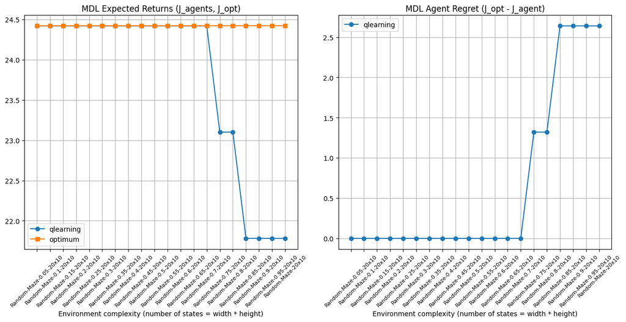

```python
def plot_regret_per_step(mixRetReg, post_J_mix, J_mix, J_hat, envs_dic, agents, axs, plot_mixture=False):

    # 3) Gather complexity list
    env_complexities = {env_name: env_complexity(env) for env_name, env in envs_dic.items()}
    env_dims = [ (env.width, env.height) for env_name, env in envs_dic.items() ]

    # Sort envs by complexity for plotting
    envs_sorted = list(envs_dic.keys())
    x_vals = envs_sorted

    m = 0
    ax = axs[0]
    ax.set_xlabel("Environment complexity (number of states = width * height)")
    if plot_mixture:
        ax.set_ylabel("MDL Expected Returns (J_agents, J_opt, J_mix, post_J_mix)")
    else:
        ax.set_title("MDL Expected Returns (J_agents, J_opt)")
    for agent_name in agents:
        y_reg = [J_hat[agent_name][env] for env in envs_sorted]
        ax.plot(x_vals, y_reg, marker=plot_markers[m], label=agent_name)
        m += 1
    if plot_mixture:
        y_reg = [J_mix[env] for env in envs_sorted]
        ax.plot(x_vals, y_reg, marker=plot_markers[m], label='mixture')
        m += 1
        y_reg = [post_J_mix[env] for env in envs_sorted]
        ax.plot(x_vals, y_reg, marker=plot_markers[m], label='post_mixture')
        m += 1
    y_reg = [env.optimal_rets for env_name, env in envs_dic.items()]
    ax.plot(x_vals, y_reg, marker=plot_markers[m], label='optimum')
    m += 1
    ax.set_xticks(x_vals)
    #ax.set_xticklabels(x_vals)
    ax.tick_params(axis='x', labelrotation=45, labelsize=8)
    ax.legend()
    ax.grid(True)

    m = 0
    ax = axs[1]
    ax.set_xlabel("Environment complexity (number of states = width * height)")
    # ax.set_ylabel("MDL Mixture Regret (J_mix - J_agent)")
    if plot_mixture:
        ax.set_title("MDL Agent Regret (J_opt - J_agent, J_opt - J_mix)")
    else:
        ax.set_title("MDL Agent Regret (J_opt - J_agent)")
    for agent_name in agents:
        y_reg = [env.optimal_rets-J_hat[agent_name][env_name] for env_name, env in envs_dic.items()]
        ax.plot(x_vals, y_reg, marker=plot_markers[m], label=agent_name)
        m += 1
    if plot_mixture:
        y_reg = [env.optimal_rets-J_mix[env_name] for env_name, env in envs_dic.items()]
        ax.plot(x_vals, y_reg, marker=plot_markers[m], label='mixture')
        m += 1
        y_reg = [env.optimal_rets-post_J_mix[env_name] for env_name, env in envs_dic.items()]
        ax.plot(x_vals, y_reg, marker=plot_markers[m], label='post_mixture')
        m += 1
    ax.set_xticks(x_vals)
    #ax.set_xticklabels(x_vals)
    ax.tick_params(axis='x', labelrotation=45, labelsize=8)
    ax.legend()
    ax.grid(True)

    # plt.show()

if __name__ == "__main__":

    rows=1
    cols=2
    hspace=0.25
    wspace=0.15
    fig, axs = plt.subplots(rows, cols, figsize=(cols*6*(1+wspace*2), rows*5*(1+hspace))) #, constrained_layout=True)
    fig.subplots_adjust(hspace=hspace, wspace=wspace)
    plot_regret_per_step(mixRetReg, post_J_mix, J_mix, J_hat, envs_dic, agents, axs)
```

```python
mode_J_meta = {}
mode_J_hat = {}
mode_Opt_Reg = {}
mode_Opt_Reg_meta = {}
mode_Reg = {}


for mode in all_modes:
    meta_agent_mode = mode

    J_meta = {}
    Reg = defaultdict(dict)
    Opt_Reg = defaultdict(dict)
    Opt_Reg_meta = defaultdict(dict)
    J_hat = defaultdict(dict)

    print(f'\nCalculating Mean Returns from MetaAgent mode={mode}...')

    for env_name, env in envs_dic.items():
        env_dim = (env.width, env.height)
        w, h = env_dim

        for agent_name in ['meta_agent']:
            df = load_trajectories(agent_name, env_name, mode, data_dir=TRAJ_DIR, force_load=True, verbose=True)
            J_meta[env_name] = compute_mean_return(df)
    mode_J_meta[mode] = J_meta

    for env_name, env in envs_dic.items():
        env_dim = (env.width, env.height)
        w, h = env_dim

        print()
        for agent_name in agents:
            df = load_trajectories(agent_name, env_name, mode, data_dir=TRAJ_DIR, verbose=False)
            J_hat[agent_name][env_name] = compute_mean_return(df)
            Reg[agent_name][env_name] = J_meta[env_name] - J_hat[agent_name][env_name]
            Opt_Reg[agent_name][env_name] = env.optimal_rets - J_hat[agent_name][env_name]
            Opt_Reg_meta[agent_name][env_name] = env.optimal_rets - J_meta[env_name]
            print(
                f"{agent_name}{' '*max(0,20-len(agent_name))} on {env_name}: "
                f"agent_returns={J_hat[agent_name][env_name]:.3f}, "
                f"optimal_returns={env.optimal_rets:.3f}, "
                f"agent_regret={Opt_Reg[agent_name][env_name]:.3f}, "
                f"meta-agent_regret={Opt_Reg_meta[agent_name][env_name]:.3f}, "
                f"meta-agent_returns={J_meta[env_name]:.3f}, "
                f"meta-agent-relative_regret={Reg[agent_name][env_name]:.3f}, "
            )

    mode_Reg[mode] = Reg
    mode_Opt_Reg[mode] = Opt_Reg
    mode_Opt_Reg_meta[mode] = Opt_Reg_meta
    mode_J_hat[mode] = J_hat
```

```
Calculating Mean Returns from MetaAgent mode=thompson...
Loading trajectories from meta_agent_Random-Maze-0.05-20x10_succ_greedy_traj_th.csv...
Loading trajectories from meta_agent_Random-Maze-0.1-20x10_succ_greedy_traj_th.csv...
Loading trajectories from meta_agent_Random-Maze-0.15-20x10_succ_greedy_traj_th.csv...
Loading trajectories from meta_agent_Random-Maze-0.2-20x10_succ_greedy_traj_th.csv...
Loading trajectories from meta_agent_Random-Maze-0.25-20x10_succ_greedy_traj_th.csv...
Loading trajectories from meta_agent_Random-Maze-0.3-20x10_succ_greedy_traj_th.csv...
Loading trajectories from meta_agent_Random-Maze-0.35-20x10_succ_greedy_traj_th.csv...
Loading trajectories from meta_agent_Random-Maze-0.4-20x10_succ_greedy_traj_th.csv...
Loading trajectories from meta_agent_Random-Maze-0.45-20x10_succ_greedy_traj_th.csv...
Loading trajectories from meta_agent_Random-Maze-0.5-20x10_succ_greedy_traj_th.csv...
Loading trajectories from meta_agent_Random-Maze-0.55-20x10_succ_greedy_traj_th.csv...
Loading trajectories from meta_agent_Random-Maze-0.6-20x10_succ_greedy_traj_th.csv...
Loading trajectories from meta_agent_Random-Maze-0.65-20x10_succ_greedy_traj_th.csv...
Loading trajectories from meta_agent_Random-Maze-0.7-20x10_succ_greedy_traj_th.csv...
Loading trajectories from meta_agent_Random-Maze-0.75-20x10_succ_greedy_traj_th.csv...
Loading trajectories from meta_agent_Random-Maze-0.8-20x10_succ_greedy_traj_th.csv...
Loading trajectories from meta_agent_Random-Maze-0.85-20x10_succ_greedy_traj_th.csv...
Loading trajectories from meta_agent_Random-Maze-0.9-20x10_succ_greedy_traj_th.csv...
Loading trajectories from meta_agent_Random-Maze-0.95-20x10_succ_greedy_traj_th.csv...
Loading trajectories from meta_agent_Random-Maze-20x10_succ_greedy_traj_th.csv...

qlearning            on Random-Maze-0.05-20x10: agent_returns=24.420, optimal_returns=24.420, agent_regret=0.000, meta-agent_regret=0.000, meta-agent_returns=24.420, meta-agent-relative_regret=0.000,

qlearning            on Random-Maze-0.1-20x10: agent_returns=24.420, optimal_returns=24.420, agent_regret=0.000, meta-agent_regret=14.999, meta-agent_returns=9.421, meta-agent-relative_regret=-14.998,

qlearning            on Random-Maze-0.15-20x10: agent_returns=24.420, optimal_returns=24.420, agent_regret=0.000, meta-agent_regret=29.997, meta-agent_returns=-5.577, meta-agent-relative_regret=-29.997,

qlearning            on Random-Maze-0.2-20x10: agent_returns=24.420, optimal_returns=24.420, agent_regret=0.000, meta-agent_regret=41.126, meta-agent_returns=-16.706, meta-agent-relative_regret=-41.126,

qlearning            on Random-Maze-0.25-20x10: agent_returns=24.420, optimal_returns=24.420, agent_regret=0.000, meta-agent_regret=74.984, meta-agent_returns=-50.564, meta-agent-relative_regret=-74.984,

qlearning            on Random-Maze-0.3-20x10: agent_returns=24.420, optimal_returns=24.420, agent_regret=0.000, meta-agent_regret=63.773, meta-agent_returns=-39.353, meta-agent-relative_regret=-63.773,

qlearning            on Random-Maze-0.35-20x10: agent_returns=24.420, optimal_returns=24.420, agent_regret=0.000, meta-agent_regret=52.709, meta-agent_returns=-28.289, meta-agent-relative_regret=-52.709,

qlearning            on Random-Maze-0.4-20x10: agent_returns=24.420, optimal_returns=24.420, agent_regret=0.000, meta-agent_regret=60.142, meta-agent_returns=-35.722, meta-agent-relative_regret=-60.142,

qlearning            on Random-Maze-0.45-20x10: agent_returns=24.420, optimal_returns=24.420, agent_regret=0.000, meta-agent_regret=57.511, meta-agent_returns=-33.091, meta-agent-relative_regret=-57.511,

```

[output cut: 68 more lines]

```
qlearning            on Random-Maze-0.65-20x10: agent_returns=24.420, optimal_returns=24.420, agent_regret=0.000, meta-agent_regret=40.920, meta-agent_returns=-16.500, meta-agent-relative_regret=-40.920,

qlearning            on Random-Maze-0.7-20x10: agent_returns=24.420, optimal_returns=24.420, agent_regret=0.000, meta-agent_regret=40.920, meta-agent_returns=-16.500, meta-agent-relative_regret=-40.920,

qlearning            on Random-Maze-0.75-20x10: agent_returns=23.100, optimal_returns=24.420, agent_regret=1.320, meta-agent_regret=40.920, meta-agent_returns=-16.500, meta-agent-relative_regret=-39.600,

qlearning            on Random-Maze-0.8-20x10: agent_returns=23.100, optimal_returns=24.420, agent_regret=1.320, meta-agent_regret=43.230, meta-agent_returns=-18.810, meta-agent-relative_regret=-41.910,

qlearning            on Random-Maze-0.85-20x10: agent_returns=21.780, optimal_returns=24.420, agent_regret=2.640, meta-agent_regret=43.230, meta-agent_returns=-18.810, meta-agent-relative_regret=-40.590,

qlearning            on Random-Maze-0.9-20x10: agent_returns=21.780, optimal_returns=24.420, agent_regret=2.640, meta-agent_regret=43.230, meta-agent_returns=-18.810, meta-agent-relative_regret=-40.590,

qlearning            on Random-Maze-0.95-20x10: agent_returns=21.780, optimal_returns=24.420, agent_regret=2.640, meta-agent_regret=43.230, meta-agent_returns=-18.810, meta-agent-relative_regret=-40.590,

qlearning            on Random-Maze-20x10: agent_returns=21.780, optimal_returns=24.420, agent_regret=2.640, meta-agent_regret=43.230, meta-agent_returns=-18.810, meta-agent-relative_regret=-40.590,
```

```python
Reg
```

```
defaultdict(dict,
            {'qlearning': {'Random-Maze-0.05-20x10': 0.0,
              'Random-Maze-0.1-20x10': 0.0,
              'Random-Maze-0.15-20x10': 0.0,
              'Random-Maze-0.2-20x10': 0.0,
              'Random-Maze-0.25-20x10': 0.0,
              'Random-Maze-0.3-20x10': 0.0,
              'Random-Maze-0.35-20x10': 0.0,
              'Random-Maze-0.4-20x10': 0.0,
              'Random-Maze-0.45-20x10': 0.0,
              'Random-Maze-0.5-20x10': 0.0,
              'Random-Maze-0.55-20x10': 0.0,
              'Random-Maze-0.6-20x10': 0.0,
              'Random-Maze-0.65-20x10': -40.92,
              'Random-Maze-0.7-20x10': -40.92,
              'Random-Maze-0.75-20x10': -39.599999999999994,
              'Random-Maze-0.8-20x10': -41.91,
              'Random-Maze-0.85-20x10': -40.59,
              'Random-Maze-0.9-20x10': -40.59,
              'Random-Maze-0.95-20x10': -40.59,
              'Random-Maze-20x10': -40.59}})
```

```python
def plot_subplot(ax, Reg, xlabel, ylabel, title, envs_dic):
    env_complexities = {env_name: env_complexity(env) for env_name, env in envs_dic.items()}
    env_dims = [ (env.width, env.height) for env_name, env in envs_dic.items() ]

    # Sort envs by complexity for plotting
    envs_sorted = list(envs_dic.keys())
    x_vals = envs_sorted

    m = 0
    for agent_name in agents:
        y_reg = [Reg[agent_name][env_name] for env_name, env in envs_dic.items()]
        ax.plot(x_vals, y_reg, marker=plot_markers[m], label=agent_name)
        m += 1
    ax.set_xlabel(xlabel)
    ax.set_ylabel(ylabel)
    ax.set_title(title)
    ax.set_xticks(x_vals)
    #ax.set_xticklabels(x_vals)
    ax.tick_params(axis='x', labelrotation=45)
    ax.legend()
    ax.grid(True)
    # plt.set_tight_layout()
    return m

def plot_returns(Opt_Reg_meta, Opt_Reg, Reg, J_meta, J_hat, J_mix, post_J_mix, axs, row, col, one_dim, mode, envs_dic, plot_mixture=False, show_regret=True):

    # 3) Gather complexity list
    env_complexities = {env_name: env_complexity(env) for env_name, env in envs_dic.items()}
    env_dims = [ (env.width, env.height) for env_name, env in envs_dic.items() ]

    # Sort envs by complexity for plotting
    envs_sorted = list(envs_dic.keys())
    x_vals = envs_sorted

    # 4) Plot MDL regret vs complexity

    if show_regret:
        ax = axs[0] if one_dim or row < 0 and col < 0 else axs[row, 0] if col < 0 else axs[0, col]
    else:
        ax = axs[row] if col < 0 else axs[col]
    xlabel = "" # Environment complexity (number of states = width * height)"
    if plot_mixture:
        title = f"{mode} MDL Expected Returns (J_agents, J_mix, J_meta, J_opt)"
    else:
        title = f"{mode} MDL Expected Returns (J_agents, J_meta, J_opt)"
    ylabel = "" # "MDL Expected Returns vs Environment Complexity"
    m = plot_subplot(ax, J_hat, xlabel, ylabel, title, envs_dic)
    if plot_mixture:
        y_reg = [J_mix[env] for env in envs_sorted]
        ax.plot(x_vals, y_reg, marker=plot_markers[m], label='mixture')
        m += 1
        y_reg = [post_J_mix[env] for env in envs_sorted]
        ax.plot(x_vals, y_reg, marker=plot_markers[m], label='post_mixture')
        m += 1
    y_reg = [J_meta[env] for env in envs_sorted]
    ax.plot(x_vals, y_reg, marker=plot_markers[m], label=f'{mode} meta-agent')
    m += 1
    y_reg = [env.optimal_rets for env_name, env in envs_dic.items()]
    ax.plot(x_vals, y_reg, marker=plot_markers[m], label='optimum')
    m += 1
    ax.legend()

    if show_regret:
        ax = axs[1] if one_dim or row < 0 and col < 0 else axs[row, 1] if col < 0 else axs[1, col]
        xlabel = "" # Environment complexity (number of states = width * height)"
        if plot_mixture:
            title = f"{mode} MDL Regret (J_opt-J_agents, J_opt-J_mix, J_opt-J_meta)"
        else:
            title = f"{mode} MDL Regret (J_opt-J_agents, J_opt-J_meta)"
        ylabel = "" # "MDL Expected Returns vs Environment Complexity"
        m = plot_subplot(ax, Opt_Reg, xlabel, ylabel, title, envs_dic)
        if plot_mixture:
            y_reg = [env.optimal_rets-J_mix[env_name] for env_name, env in envs_dic.items()]
            ax.plot(x_vals, y_reg, marker=plot_markers[m], label='mixture')
            m += 1
            y_reg = [env.optimal_rets-post_J_mix[env_name] for env_name, env in envs_dic.items()]
            ax.plot(x_vals, y_reg, marker=plot_markers[m], label='post_mixture')
            m += 1
        y_reg = [env.optimal_rets-J_meta[env_name] for env_name, env in envs_dic.items()]
        ax.plot(x_vals, y_reg, marker=plot_markers[m], label=f'{mode} meta-agent')
        m += 1
        ax.legend()
```

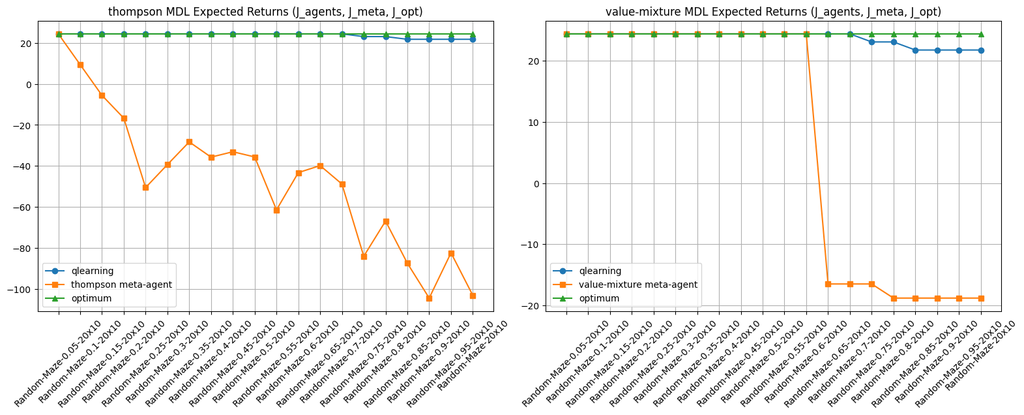

```python
#fig, axs = plt.subplots(3, 3, figsize=(15, 15), constrained_layout=True)

hspace=0.25
wspace=0.15

show_regret = False

if False:
    rows=len(all_modes)
    cols=1 + show_regret*1
    fig, axs = plt.subplots(rows, cols, figsize=(cols*6*(1+wspace*2), rows*5*(1+hspace)), constrained_layout=True)
    # fig.subplots_adjust(hspace=hspace, wspace=wspace)
    one_dim = rows == 1 or cols == 1

    col = -1
    for row, mode in enumerate(all_modes):

        plot_returns(mode_Opt_Reg_meta[mode], mode_Opt_Reg[mode], mode_Reg[mode], mode_J_meta[mode], mode_J_hat[mode], J_mix, post_J_mix, axs, row, col, one_dim, mode, envs_dic, show_regret=show_regret)
else:
    rows=1 + show_regret*1
    cols=len(all_modes)
    fig, axs = plt.subplots(rows, cols, figsize=(cols*6*(1+wspace*2), rows*5*(1+hspace)), constrained_layout=True)
    # fig.subplots_adjust(hspace=hspace, wspace=wspace)
    one_dim = cols == 1 or rows == 1

    row = -1
    for col, mode in enumerate(all_modes):

        plot_returns(mode_Opt_Reg_meta[mode], mode_Opt_Reg[mode], mode_Reg[mode], mode_J_meta[mode], mode_J_hat[mode], J_mix, post_J_mix, axs, row, col, one_dim, mode, envs_dic, show_regret=show_regret)
```

```python
# -----------------------
# MDL-Regret GRID (MIXTURE-OF-EXPERTS BASELINE)
# -----------------------

def compute_MDL_Regret_grid_moe(agents, envs_dic, env_agent_desc_len, mode, greedy, traj_dir: str = DATA_DIR, qtable_dir: str = DATA_DIR):
    """
    Compute Agent-side MDL-Regret metrics for all (agent, env) pairs,
    using a mixture-of-experts compressor as the baseline.

    For each environment:
      - Build expert policies for each agent.
      - Run mixture-of-experts over the combined agent logs.
      - For each agent A:
          * mixture_bits_per_step[A, env]   (mixture codes A's steps)
          * agent_bits_per_step[A, env]     (agent A codes its own steps)
          * MDL_Regret[A, env] = agent_bps - mixture_bps

    Returns:
      MDL_Regret_vals[agent][env] = dict with keys:
        - agent_bits_per_step
        - mixture_bits_per_step
        - MDL_Regret
        - posterior_weight
    """
    # Precompute policies
    if calc_policies_from_Q_table:
        policies = precompute_policies_from_Q_table(agents, envs_dic, data_dir=qtable_dir, temperature=temperature_to_build_stochastic_policy)
    else:
        policies = precompute_policies(agents, envs_dic, data_dir=traj_dir)

    print()
    MDL_Regret_vals = defaultdict(dict)
    env_posterior_weights = {}
    for env_name, env in envs_dic.items():
        env_dim = (env.width, env.height)

        print(f'\nCalculating MDL-Regret for Env: {env_name} grid:')
        agent_desc_len = env_agent_desc_len[env_name]
        offline_mixture_bps_env, offline_agent_bps_env, posterior_weights, posterior_weightsA, offline_global_mixture_bps, all_agent_bits_per_agent = mixture_of_experts_env(
            agents, env_name, policies[0], agent_desc_len, greedy=greedy, data_dir=traj_dir, use_median=use_median_to_calc_mdl_bits_per_step
        )

        meta.reset_belief()
        meta_agent_self_bps_env = calc_meta_agent_bps_env(
            meta,
            env_name,
            { 'meta_agent': np.sum([offline_agent_bps_env[name]*posterior_weights[name] for name in agent_names]) },
            mode,
            greedy,
            data_dir=DATA_DIR,
            use_median=use_median_to_calc_mdl_bits_per_step,
        )

        meta.reset_belief()
        meta_agent_bps_env = meta_agent_bps_on_agents_trajectory_env(
            agents,
            env_name,
            agent_desc_len,
            meta,
            mode,
            greedy,
            data_dir=DATA_DIR,
            use_median=use_median_to_calc_mdl_bits_per_step,
        )

        env_posterior_weights[env_name] = posterior_weights
        for agent_name in agents:
            # print(f'Agent: {agent_name}...')
            agent_bps = offline_agent_bps_env[agent_name]
            mix_bps = offline_mixture_bps_env[agent_name]
            MDL_Regret = agent_bps - mix_bps
            MDL_Mix_Regret = mix_bps - offline_global_mixture_bps
            MDL_MAS_Regret = agent_bps - meta_agent_self_bps_env
            MDL_MAS_Mix_Regret = meta_agent_self_bps_env - offline_global_mixture_bps
            MDL_MA_Regret = agent_bps - meta_agent_bps_env[agent_name]
            MDL_MA_Mix_Regret = meta_agent_bps_env[agent_name] - offline_global_mixture_bps

            MDL_Regret_vals[agent_name][env_name] = {
                "global_mixture_bits_per_step": offline_global_mixture_bps,
                "agent_bits_per_step": agent_bps,
                "mixture_bits_per_step": mix_bps,
                "MDL-Regret": MDL_Regret,
                "MDL-Mix-Regret": MDL_Mix_Regret, # Agent Solomonoff Excess Bits
                "meta_agent_bits_per_step": meta_agent_bps_env[agent_name],
                "MDL-MA-Regret": MDL_MA_Regret,
                "MDL-MA-Mix-Regret": MDL_MA_Mix_Regret, # Agent Solomonoff Excess Bits
                "meta_agent_self_bits_per_step": meta_agent_self_bps_env,
                "MDL-MAS-Regret": MDL_MAS_Regret,
                "MDL-MAS-Mix-Regret": MDL_MAS_Mix_Regret, # Agent Solomonoff Excess Bits
                "posterior_weight": posterior_weights.get(agent_name, float("nan")),
            }

    return MDL_Regret_vals, env_posterior_weights, policies
```

```python
all_action_space = set()
qs = []
for nu, (env_name, env) in enumerate(tqdm(envs_dic.items())):

    state_len = len(env.reset())
    env.update_r_wall(wall_reward_like_cliff)

    Q_path=f"./logs{qtable_sub_dir}/{agent_name}_{env.name}{('-'+str(state_len)) if save_full_state_info and state_len != default_state_len else ''}_qtable.csv"

    q, action_space = load_qtable(agent_name, env.name, data_dir=f"./logs{qtable_sub_dir}/",
                                  state_len=state_len, default_state_len=default_state_len)

    # q = make_fake_q(env.walls)
    qs.append(q)
    all_action_space.update(action_space)

all_action_space = sorted(list(all_action_space))
```

```python
# -----------------------
# MAIN: COMPUTE & PLOT
# -----------------------

if __name__ == "__main__":

    # Meta-agent only needs an env "template" for width/height semantics
    meta = MetaAgent(env_template=list(envs_dic.values())[0], q_tables=qs, action_space=all_action_space, epsilon=0.0, use_belief_weighted_Q=False) # , unknown_rew_range = True)

    greedy=use_greedy_policy_to_build_trajectories_from_saved_Q_table  # greedy must be cohere with global var because load_trajectories use it

    bits_rows = []
    bits_cols = ['mode', 'greedy', 'env_name', 'agent_name',
                 'global_mixture_bits_per_step', 'agent_bits_per_step',
                 'mixture_bits_per_step', 'MDL-Regret', 'MDL-Mix-Regret',
                 'meta_agent_bits_per_step', 'MDL-MA-Regret', 'MDL-MA-Mix-Regret',
                 'meta_agent_self_bits_per_step', 'MDL-MAS-Regret', 'MDL-MAS-Mix-Regret',
                 'posterior_weight']

    mode_MDL_Regret_vals = {}
    for mode in all_modes[:]:
        meta_agent_mode = mode

        print(f"\n\nMDL-Regret metrics ({mode}, greedy={greedy}):")

        # 1) Agent-side MDL-Regret (using mixture-of-experts baseline)
        MDL_Regret_vals, env_posterior_weights, policies = compute_MDL_Regret_grid_moe(agents, envs_dic, env_agent_desc_len, meta_agent_mode, greedy, traj_dir=TRAJ_DIR, qtable_dir=QTABLE_DIR)

        print(f"\nMDL-Regret metrics ({mode}, greedy={greedy}):")
        for env_name in envs:
            for agent_name in agents:
                m = MDL_Regret_vals[agent_name][env_name]
                print(
                    f"{agent_name}{' '*max(0,20-len(agent_name))} on {env_name}: "
                    f"agent_bps={m['agent_bits_per_step']:.3f}, "
                    f"mixture_bps={m['mixture_bits_per_step']:.3f}, "
                    f"global_mixture_bps={m['global_mixture_bits_per_step']:.3f}, "
                    f"MDL-Regret={m['MDL-Regret']:.6f}, "
                    f"MDL-Mix-Regret={m['MDL-Mix-Regret']:.6f}, "
                    f"meta_agent_bps={m['meta_agent_bits_per_step']:.3f}, "
                    f"MDL-MA-Regret={m['MDL-MA-Regret']:.6f}, "
                    f"MDL-MA-Mix-Regret={m['MDL-MA-Mix-Regret']:.6f}, "
                    f"meta_self_agent_bps={m['meta_agent_self_bits_per_step']:.3f}, "
                    f"MDL-MAS-Regret={m['MDL-MAS-Regret']:.6f}, "
                    f"MDL-MAS-Mix-Regret={m['MDL-MAS-Mix-Regret']:.6f}, "
                    f"posterior_weight={m["posterior_weight"]:.6f}"
                )

                row = [mode, greedy, env_name, agent_name,
                    m['global_mixture_bits_per_step'],
                    m['agent_bits_per_step'],
                    m['mixture_bits_per_step'], m['MDL-Regret'], m['MDL-Mix-Regret'],
                    m['meta_agent_bits_per_step'], m['MDL-MA-Regret'], m['MDL-MA-Mix-Regret'],
                    m['meta_agent_self_bits_per_step'], m['MDL-MAS-Regret'], m['MDL-MAS-Mix-Regret'],
                    m["posterior_weight"]]
                bits_rows.append(row)
            print()
        mode_MDL_Regret_vals[mode] = MDL_Regret_vals

    bits_df = pd.DataFrame(bits_rows, columns=bits_cols)
    bits_df.to_csv(DATA_DIR+'/env_meta_agent_bits.csv')
```

```
MDL-Regret metrics (thompson, greedy=True):


Precomputing Policies for Env: Random-Maze-0.05-20x10 grid:
Agent: qlearning...

Precomputing Policies for Env: Random-Maze-0.1-20x10 grid:
Agent: qlearning...

Precomputing Policies for Env: Random-Maze-0.15-20x10 grid:
Agent: qlearning...

Precomputing Policies for Env: Random-Maze-0.2-20x10 grid:
Agent: qlearning...

Precomputing Policies for Env: Random-Maze-0.25-20x10 grid:
Agent: qlearning...

Precomputing Policies for Env: Random-Maze-0.3-20x10 grid:
Agent: qlearning...

Precomputing Policies for Env: Random-Maze-0.35-20x10 grid:
Agent: qlearning...

Precomputing Policies for Env: Random-Maze-0.4-20x10 grid:
Agent: qlearning...

Precomputing Policies for Env: Random-Maze-0.45-20x10 grid:
Agent: qlearning...

Precomputing Policies for Env: Random-Maze-0.5-20x10 grid:
Agent: qlearning...

Precomputing Policies for Env: Random-Maze-0.55-20x10 grid:
Agent: qlearning...

Precomputing Policies for Env: Random-Maze-0.6-20x10 grid:
Agent: qlearning...

Precomputing Policies for Env: Random-Maze-0.65-20x10 grid:
```

[output cut: 10 more lines]

```

Precomputing Policies for Env: Random-Maze-0.85-20x10 grid:
Agent: qlearning...

Precomputing Policies for Env: Random-Maze-0.9-20x10 grid:
Agent: qlearning...

Precomputing Policies for Env: Random-Maze-0.95-20x10 grid:
Agent: qlearning...

Precomputing Policies for Env: Random-Maze-20x10 grid:
Agent: qlearning...


Calculating MDL-Regret for Env: Random-Maze-0.05-20x10 grid:
```

```
Calculating MDL-Regret for Env: Random-Maze-0.1-20x10 grid:
```

```
Calculating MDL-Regret for Env: Random-Maze-0.15-20x10 grid:
```

```
Calculating MDL-Regret for Env: Random-Maze-0.2-20x10 grid:
```

```
Calculating MDL-Regret for Env: Random-Maze-0.25-20x10 grid:
```

```
Calculating MDL-Regret for Env: Random-Maze-0.3-20x10 grid:
```

```
Calculating MDL-Regret for Env: Random-Maze-0.35-20x10 grid:
```

```
Calculating MDL-Regret for Env: Random-Maze-0.4-20x10 grid:
```

```
Calculating MDL-Regret for Env: Random-Maze-0.45-20x10 grid:
```

```
Calculating MDL-Regret for Env: Random-Maze-0.5-20x10 grid:
```

```
Calculating MDL-Regret for Env: Random-Maze-0.55-20x10 grid:
```

```
Calculating MDL-Regret for Env: Random-Maze-0.6-20x10 grid:
```

```
Calculating MDL-Regret for Env: Random-Maze-0.65-20x10 grid:
```

```
Calculating MDL-Regret for Env: Random-Maze-0.7-20x10 grid:
```

```
Calculating MDL-Regret for Env: Random-Maze-0.75-20x10 grid:
```

```
Calculating MDL-Regret for Env: Random-Maze-0.8-20x10 grid:
```

```
Calculating MDL-Regret for Env: Random-Maze-0.85-20x10 grid:
```

```
Calculating MDL-Regret for Env: Random-Maze-0.9-20x10 grid:
```

```
Calculating MDL-Regret for Env: Random-Maze-0.95-20x10 grid:
```

```
Calculating MDL-Regret for Env: Random-Maze-20x10 grid:
```

```
MDL-Regret metrics (thompson, greedy=True):
qlearning            on Random-Maze-0.05-20x10: agent_bps=0.982, mixture_bps=0.982, global_mixture_bps=0.982, MDL-Regret=0.000000, MDL-Mix-Regret=0.000000, meta_agent_bps=0.982, MDL-MA-Regret=0.000000, MDL-MA-Mix-Regret=-0.000000, meta_self_agent_bps=0.967, MDL-MAS-Regret=0.014393, MDL-MAS-Mix-Regre…

qlearning            on Random-Maze-0.1-20x10: agent_bps=0.934, mixture_bps=0.934, global_mixture_bps=0.934, MDL-Regret=0.000000, MDL-Mix-Regret=0.000000, meta_agent_bps=0.969, MDL-MA-Regret=-0.035000, MDL-MA-Mix-Regret=0.035000, meta_self_agent_bps=0.945, MDL-MAS-Regret=-0.011156, MDL-MAS-Mix-Regre…

qlearning            on Random-Maze-0.15-20x10: agent_bps=0.904, mixture_bps=0.904, global_mixture_bps=0.904, MDL-Regret=0.000000, MDL-Mix-Regret=0.000000, meta_agent_bps=0.970, MDL-MA-Regret=-0.066489, MDL-MA-Mix-Regret=0.066489, meta_self_agent_bps=0.932, MDL-MAS-Regret=-0.028240, MDL-MAS-Mix-Regr…

qlearning            on Random-Maze-0.2-20x10: agent_bps=0.866, mixture_bps=0.866, global_mixture_bps=0.866, MDL-Regret=0.000000, MDL-Mix-Regret=0.000000, meta_agent_bps=0.954, MDL-MA-Regret=-0.087783, MDL-MA-Mix-Regret=0.087783, meta_self_agent_bps=0.912, MDL-MAS-Regret=-0.046037, MDL-MAS-Mix-Regre…

qlearning            on Random-Maze-0.25-20x10: agent_bps=0.726, mixture_bps=0.726, global_mixture_bps=0.726, MDL-Regret=0.000000, MDL-Mix-Regret=0.000000, meta_agent_bps=1.143, MDL-MA-Regret=-0.416483, MDL-MA-Mix-Regret=0.416483, meta_self_agent_bps=0.859, MDL-MAS-Regret=-0.132474, MDL-MAS-Mix-Regr…

qlearning            on Random-Maze-0.3-20x10: agent_bps=0.679, mixture_bps=0.679, global_mixture_bps=0.679, MDL-Regret=0.000000, MDL-Mix-Regret=0.000000, meta_agent_bps=1.153, MDL-MA-Regret=-0.473434, MDL-MA-Mix-Regret=0.473434, meta_self_agent_bps=0.792, MDL-MAS-Regret=-0.112320, MDL-MAS-Mix-Regre…

qlearning            on Random-Maze-0.35-20x10: agent_bps=0.636, mixture_bps=0.636, global_mixture_bps=0.636, MDL-Regret=0.000000, MDL-Mix-Regret=0.000000, meta_agent_bps=1.148, MDL-MA-Regret=-0.512642, MDL-MA-Mix-Regret=0.512642, meta_self_agent_bps=0.751, MDL-MAS-Regret=-0.115571, MDL-MAS-Mix-Regr…

qlearning            on Random-Maze-0.4-20x10: agent_bps=0.621, mixture_bps=0.621, global_mixture_bps=0.621, MDL-Regret=0.000000, MDL-Mix-Regret=0.000000, meta_agent_bps=1.145, MDL-MA-Regret=-0.523862, MDL-MA-Mix-Regret=0.523862, meta_self_agent_bps=0.720, MDL-MAS-Regret=-0.098773, MDL-MAS-Mix-Regre…

qlearning            on Random-Maze-0.45-20x10: agent_bps=0.582, mixture_bps=0.582, global_mixture_bps=0.582, MDL-Regret=0.000000, MDL-Mix-Regret=0.000000, meta_agent_bps=1.146, MDL-MA-Regret=-0.563274, MDL-MA-Mix-Regret=0.563274, meta_self_agent_bps=0.654, MDL-MAS-Regret=-0.071116, MDL-MAS-Mix-Regr…

qlearning            on Random-Maze-0.5-20x10: agent_bps=0.574, mixture_bps=0.574, global_mixture_bps=0.574, MDL-Regret=0.000000, MDL-Mix-Regret=0.000000, meta_agent_bps=1.146, MDL-MA-Regret=-0.571910, MDL-MA-Mix-Regret=0.571910, meta_self_agent_bps=0.654, MDL-MAS-Regret=-0.079851, MDL-MAS-Mix-Regre…

qlearning            on Random-Maze-0.55-20x10: agent_bps=0.580, mixture_bps=0.580, global_mixture_bps=0.580, MDL-Regret=0.000000, MDL-Mix-Regret=0.000000, meta_agent_bps=1.104, MDL-MA-Regret=-0.524118, MDL-MA-Mix-Regret=0.524118, meta_self_agent_bps=0.656, MDL-MAS-Regret=-0.076823, MDL-MAS-Mix-Regr…

qlearning            on Random-Maze-0.6-20x10: agent_bps=0.564, mixture_bps=0.564, global_mixture_bps=0.564, MDL-Regret=0.000000, MDL-Mix-Regret=0.000000, meta_agent_bps=1.112, MDL-MA-Regret=-0.547841, MDL-MA-Mix-Regret=0.547841, meta_self_agent_bps=0.678, MDL-MAS-Regret=-0.113729, MDL-MAS-Mix-Regre…

qlearning            on Random-Maze-0.65-20x10: agent_bps=0.501, mixture_bps=0.501, global_mixture_bps=0.501, MDL-Regret=0.000000, MDL-Mix-Regret=0.000000, meta_agent_bps=1.071, MDL-MA-Regret=-0.570253, MDL-MA-Mix-Regret=0.570253, meta_self_agent_bps=0.617, MDL-MAS-Regret=-0.115476, MDL-MAS-Mix-Regr…
```

[output cut: 82 more lines]

```
Calculating MDL-Regret for Env: Random-Maze-0.1-20x10 grid:
```

```
Calculating MDL-Regret for Env: Random-Maze-0.15-20x10 grid:
```

```
Calculating MDL-Regret for Env: Random-Maze-0.2-20x10 grid:
```

```
Calculating MDL-Regret for Env: Random-Maze-0.25-20x10 grid:
```

```
Calculating MDL-Regret for Env: Random-Maze-0.3-20x10 grid:
```

```
Calculating MDL-Regret for Env: Random-Maze-0.35-20x10 grid:
```

```
Calculating MDL-Regret for Env: Random-Maze-0.4-20x10 grid:
```

```
Calculating MDL-Regret for Env: Random-Maze-0.45-20x10 grid:
```

```
Calculating MDL-Regret for Env: Random-Maze-0.5-20x10 grid:
```

```
Calculating MDL-Regret for Env: Random-Maze-0.55-20x10 grid:
```

```
Calculating MDL-Regret for Env: Random-Maze-0.6-20x10 grid:
```

```
Calculating MDL-Regret for Env: Random-Maze-0.65-20x10 grid:
```

```
Calculating MDL-Regret for Env: Random-Maze-0.7-20x10 grid:
```

```
Calculating MDL-Regret for Env: Random-Maze-0.75-20x10 grid:
```

```
Calculating MDL-Regret for Env: Random-Maze-0.8-20x10 grid:
```

```
Calculating MDL-Regret for Env: Random-Maze-0.85-20x10 grid:
```

```
Calculating MDL-Regret for Env: Random-Maze-0.9-20x10 grid:
```

```
Calculating MDL-Regret for Env: Random-Maze-0.95-20x10 grid:
```

```
Calculating MDL-Regret for Env: Random-Maze-20x10 grid:
```

```
MDL-Regret metrics (value-mixture, greedy=True):
qlearning            on Random-Maze-0.05-20x10: agent_bps=0.982, mixture_bps=0.982, global_mixture_bps=0.982, MDL-Regret=0.000000, MDL-Mix-Regret=0.000000, meta_agent_bps=1.290, MDL-MA-Regret=-0.308095, MDL-MA-Mix-Regret=0.308095, meta_self_agent_bps=0.449, MDL-MAS-Regret=0.532559, MDL-MAS-Mix-Regre…

qlearning            on Random-Maze-0.1-20x10: agent_bps=0.934, mixture_bps=0.934, global_mixture_bps=0.934, MDL-Regret=0.000000, MDL-Mix-Regret=0.000000, meta_agent_bps=1.138, MDL-MA-Regret=-0.203785, MDL-MA-Mix-Regret=0.203785, meta_self_agent_bps=0.449, MDL-MAS-Regret=0.484607, MDL-MAS-Mix-Regret…

qlearning            on Random-Maze-0.15-20x10: agent_bps=0.904, mixture_bps=0.904, global_mixture_bps=0.904, MDL-Regret=0.000000, MDL-Mix-Regret=0.000000, meta_agent_bps=1.126, MDL-MA-Regret=-0.222072, MDL-MA-Mix-Regret=0.222072, meta_self_agent_bps=0.449, MDL-MAS-Regret=0.454553, MDL-MAS-Mix-Regre…

qlearning            on Random-Maze-0.2-20x10: agent_bps=0.866, mixture_bps=0.866, global_mixture_bps=0.866, MDL-Regret=0.000000, MDL-Mix-Regret=0.000000, meta_agent_bps=1.043, MDL-MA-Regret=-0.176576, MDL-MA-Mix-Regret=0.176576, meta_self_agent_bps=0.449, MDL-MAS-Regret=0.417135, MDL-MAS-Mix-Regret…

qlearning            on Random-Maze-0.25-20x10: agent_bps=0.726, mixture_bps=0.726, global_mixture_bps=0.726, MDL-Regret=0.000000, MDL-Mix-Regret=0.000000, meta_agent_bps=1.039, MDL-MA-Regret=-0.312915, MDL-MA-Mix-Regret=0.312915, meta_self_agent_bps=0.449, MDL-MAS-Regret=0.276927, MDL-MAS-Mix-Regre…

qlearning            on Random-Maze-0.3-20x10: agent_bps=0.679, mixture_bps=0.679, global_mixture_bps=0.679, MDL-Regret=0.000000, MDL-Mix-Regret=0.000000, meta_agent_bps=0.962, MDL-MA-Regret=-0.282773, MDL-MA-Mix-Regret=0.282773, meta_self_agent_bps=0.449, MDL-MAS-Regret=0.230026, MDL-MAS-Mix-Regret…

qlearning            on Random-Maze-0.35-20x10: agent_bps=0.636, mixture_bps=0.636, global_mixture_bps=0.636, MDL-Regret=0.000000, MDL-Mix-Regret=0.000000, meta_agent_bps=0.812, MDL-MA-Regret=-0.176527, MDL-MA-Mix-Regret=0.176527, meta_self_agent_bps=0.449, MDL-MAS-Regret=0.186329, MDL-MAS-Mix-Regre…

qlearning            on Random-Maze-0.4-20x10: agent_bps=0.621, mixture_bps=0.621, global_mixture_bps=0.621, MDL-Regret=0.000000, MDL-Mix-Regret=0.000000, meta_agent_bps=0.834, MDL-MA-Regret=-0.213068, MDL-MA-Mix-Regret=0.213068, meta_self_agent_bps=0.449, MDL-MAS-Regret=0.171573, MDL-MAS-Mix-Regret…

qlearning            on Random-Maze-0.45-20x10: agent_bps=0.582, mixture_bps=0.582, global_mixture_bps=0.582, MDL-Regret=0.000000, MDL-Mix-Regret=0.000000, meta_agent_bps=0.744, MDL-MA-Regret=-0.161866, MDL-MA-Mix-Regret=0.161866, meta_self_agent_bps=0.449, MDL-MAS-Regret=0.133208, MDL-MAS-Mix-Regre…

qlearning            on Random-Maze-0.5-20x10: agent_bps=0.574, mixture_bps=0.574, global_mixture_bps=0.574, MDL-Regret=0.000000, MDL-Mix-Regret=0.000000, meta_agent_bps=0.768, MDL-MA-Regret=-0.194271, MDL-MA-Mix-Regret=0.194271, meta_self_agent_bps=0.449, MDL-MAS-Regret=0.124807, MDL-MAS-Mix-Regret…

qlearning            on Random-Maze-0.55-20x10: agent_bps=0.580, mixture_bps=0.580, global_mixture_bps=0.580, MDL-Regret=0.000000, MDL-Mix-Regret=0.000000, meta_agent_bps=0.632, MDL-MA-Regret=-0.052150, MDL-MA-Mix-Regret=0.052150, meta_self_agent_bps=0.449, MDL-MAS-Regret=0.130359, MDL-MAS-Mix-Regre…

qlearning            on Random-Maze-0.6-20x10: agent_bps=0.564, mixture_bps=0.564, global_mixture_bps=0.564, MDL-Regret=0.000000, MDL-Mix-Regret=0.000000, meta_agent_bps=0.595, MDL-MA-Regret=-0.030380, MDL-MA-Mix-Regret=0.030380, meta_self_agent_bps=0.449, MDL-MAS-Regret=0.114970, MDL-MAS-Mix-Regret…

qlearning            on Random-Maze-0.65-20x10: agent_bps=0.501, mixture_bps=0.501, global_mixture_bps=0.501, MDL-Regret=0.000000, MDL-Mix-Regret=0.000000, meta_agent_bps=0.590, MDL-MA-Regret=-0.089042, MDL-MA-Mix-Regret=0.089042, meta_self_agent_bps=0.808, MDL-MAS-Regret=-0.306980, MDL-MAS-Mix-Regr…
```

[output cut: 14 more lines]

```python
def plot_bits_per_step(MDL_Regret_vals, mode, greedy, envs, agents, axs, row=-1, col=-1, one_dim=False, legend_loc=None, framealpha=0.5, show_global_mixture=True, show_regret=True):

    # 3) Gather complexity list
    env_complexities = {env_name: env_complexity(env) for env_name, env in envs_dic.items()}
    env_dims = [ (env.width, env.height) for env_name, env in envs_dic.items() ]

    # Sort envs by complexity for plotting
    envs_sorted = list(envs_dic.keys())
    x_vals = envs_sorted

    if show_regret:
        ax = axs[0] if one_dim or row < 0 and col < 0 else axs[row, 0] if col < 0 else axs[0, col]
    else:
        ax = axs[row] if col < 0 else axs[col]
    # ax.set_xlabel("Environment")
    ax.set_ylabel("Meta-Agent bits per step")
    ax.set_title(f"{mode} Meta-Agent bits per step")

    m = 0
    for agent_name in agents:
        y_mdl_regret = [MDL_Regret_vals[agent_name][env]["agent_bits_per_step"] for env in envs_sorted]
        ax.plot(x_vals, y_mdl_regret, marker=plot_markers[m], label=agent_name)
        m += 1
        # y_mdl_regret = [MDL_Regret_vals[agent_name][env]["meta_agent_bits_per_step"] for env in envs_sorted]
        # ax.plot(x_vals, y_mdl_regret, marker=plot_markers[m], label=f"{agent_name}_meta_agent")
        # m += 1
    if show_global_mixture:
        y_mdl_regret = [MDL_Regret_vals[agent_name][env]["global_mixture_bits_per_step"] for env in envs_sorted]
        ax.plot(x_vals, y_mdl_regret, marker=plot_markers[m], label='global_mixture')
        m += 1
    y_mdl_regret = [MDL_Regret_vals[agent_name][env]["meta_agent_self_bits_per_step"] for env in envs_sorted]
    ax.plot(x_vals, y_mdl_regret, marker=plot_markers[m], label=f'{mode} meta_agent')
    m += 1
    ax.set_xticks(x_vals)
    #ax.set_xticklabels(x_vals)
    ax.tick_params(axis='x', labelrotation=45, labelsize=8)
    if legend_loc is None:
        ax.legend()
    else:
        ax.legend(loc=legend_loc, framealpha=framealpha)
    ax.grid(True)

    if show_regret:
        type_letter = 'M'
        baseline1 = 'Meta-Agent'
        regret_name1 = "MDL-MA-Regret"
        type_letter = 'S'
        baseline2 = 'Meta-Agent-Self'
        regret_name2 = "MDL-MAS-Regret"
        ax = axs[1] if one_dim or row < 0 and col < 0 else axs[row, 1] if col < 0 else axs[1, col]
        # ax.set_xlabel("Environment")
        ax.set_ylabel(f"MDL-MAS-Regret (excess bits per step)")
        ax.set_title(f"{mode} MDL-MAS-Regret (Agent - {baseline2})")

        m = 0
        for agent_name in agents:
            # y_mdl_regret = [MDL_Regret_vals[agent_name][env][regret_name1] for env in envs_sorted]
            # ax.plot(x_vals, y_mdl_regret, marker=plot_markers[m], label=f'{agent_name}-{baseline1}')
            # m += 1
            y_mdl_regret = [MDL_Regret_vals[agent_name][env][regret_name2] for env in envs_sorted]
            ax.plot(x_vals, y_mdl_regret, marker=plot_markers[m], label=f'{agent_name}-{baseline2}')
            m += 1
        ax.set_xticks(x_vals)
        #ax.set_xticklabels(x_vals)
        ax.tick_params(axis='x', labelrotation=45, labelsize=8)
        ax.legend()
        ax.grid(True)

    if row < 0 and col < 0:
        plt.show()
```

```python
def action_prob_len(Q, obs, act, greedy, temperature):
    qvals = Q.get(obs)
    if qvals is None:
        # unknown state in table: fall back to random
        return math.log(1/4)
    if greedy and not force_stochastic_action_probability:
        max_val = float(qvals.max())
        best_actions = np.flatnonzero(np.isclose(qvals, max_val)).tolist()
        if act in best_actions:
            p = 1/len(best_actions)
        else:
            p = 1e-12
    else:
        probs = softmax_row(qvals, temperature)
        p = probs[int(act)]
        if p <= 0.0:
            p = 1e-12  # small epsilon to avoid -inf

    return p, -math.log2(p)
```

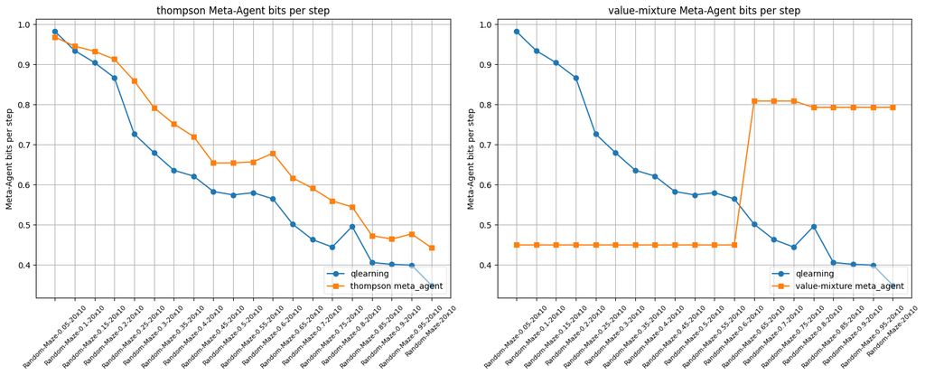

```python
if __name__ == "__main__":

    if False:
        rows=len(all_modes)
        cols=1 + show_regret*1
        hspace=0.25
        wspace=0.15
        fig, axs = plt.subplots(rows, cols, figsize=(cols*6*(1+wspace*2), rows*5*(1+hspace)), constrained_layout=True)
        # fig.subplots_adjust(hspace=hspace, wspace=wspace)

        col = -1
        for row, mode in enumerate(all_modes):
            meta_agent_mode = mode

            plot_bits_per_step(mode_MDL_Regret_vals[mode], mode, greedy, envs, agents, axs, row, col, one_dim=(rows==1), legend_loc='lower right', show_global_mixture=False, show_regret=show_regret)
    else:
        rows=1 + show_regret*1
        cols=len(all_modes)
        hspace=0.25
        wspace=0.15
        fig, axs = plt.subplots(rows, cols, figsize=(cols*6*(1+wspace*2), rows*5*(1+hspace)), constrained_layout=True)
        # fig.subplots_adjust(hspace=hspace, wspace=wspace)

        row=-1
        for col, mode in enumerate(all_modes):
            meta_agent_mode = mode

            plot_bits_per_step(mode_MDL_Regret_vals[mode], mode, greedy, envs, agents, axs, row, col, one_dim=(cols==1), legend_loc='lower right', show_global_mixture=False, show_regret=show_regret)
```

```python
if __name__ == "__main__":


    all_data_dic = {}
    all_data_dic['mode_Opt_Reg_meta'] = mode_Opt_Reg_meta
    all_data_dic['mode_Opt_Reg'] = mode_Opt_Reg
    all_data_dic['mode_Reg'] = mode_Reg
    all_data_dic['mode_J_meta'] = mode_J_meta
    all_data_dic['mode_J_hat'] = mode_J_hat
    all_data_dic['J_mix'] = J_mix
    all_data_dic['post_J_mix'] = post_J_mix
    all_data_dic['mode_MDL_Regret_vals'] = mode_MDL_Regret_vals
    # all_data_dic['ts_belief_df'] = ts_belief_df
    # all_data_dic['vm_belief_df'] = vm_belief_df

    import pickle

    with open(f'{env_name} chart_data-N={N}-no_belief.pkl', 'wb') as pkl_file:
        pickle.dump(dict(all_data_dic), pkl_file, protocol=pickle.HIGHEST_PROTOCOL) # Use highest protocol for best performance
```

```python
force_small = False
mode = 'thompson'
print(f'mode={mode}, greedy{greedy}')

for env_name, env in envs_dic.items():
    env_dim = (env.width, env.height)
    w, h = (env.width, env.height)

    # meta = env_meta_agents[env_name]

    print()
    obs = env.reset()
    env.greedy_agent = greedy

    ep = -1
    done = False
    next_obs = obs
    while next_obs != env.goal:

        obs = env.reset()
        ep += 1
        # if ep == 0:
        #     print(f'{env.name} env.start_state={obs}')

        if True:
            row , best_traj = meta.run_episode(env,
                                              acting_mode=mode, #  "value-mixture"/"thompson"
                                              episode=ep,
                                              start_state=obs,
                                              max_steps=5*(env.width+env.height) if force_small else env.width*env.height*5,
                                              greedy=greedy,
                                              normalize=normalize_q_values_in_value_mixture)

            next_obs = best_traj[-1]

    df=pd.DataFrame(row)

    # print()
    # print(df)
    # print()
    env.print_grid(trajectory=best_traj)
    # print()
```

```
mode=thompson, greedyTrue

Random-Maze-0.05-20x10
· · · · · · · · · · · · · · · · · · · G
· · · · · · · · · · · · · · · · · · · ↑
· · · · · · · · · · · · · · · · · · · ↑
· · · · · · · · · · · · · · # · · · · ↑
· · · · · · · · · · · · · · · · # → → ↑
· · · · · · · · · · · · · → → → → ↑ · ·
· · · · · · · · · · # · · ↑ · · · · · ·
· · · · · · · · · · → → → ↑ · · · · · ·
· · · → → → → → → → ↑ · · · · · · · · ·
S → → ↑ · · · · · · · · · · · · · · · ·



Random-Maze-0.1-20x10
· · · · · · · → → → → → → → → → → → → G
· · · · · · · ↑ · · · · · · · · · · · ·
· · · · · · · ↑ · · · · · · # · · · · ·
· · · · · · · ↑ · · # · · · # · · · · ·
· · · · · · · ↑ · · · · · · · · # · · ·
· · · · · · · ↑ · · # · · · · · · · · ·
· · # · · · · ↑ · · # · · · · · · · · ·
· · · → → → → ↑ · · · · · · · · · · · ·
· · · ↑ · · · · · · · · · · · · · · · ·
S → → ↑ · · · · · · · · · · · · · · · ·



Random-Maze-0.15-20x10
· · · · · · · · · · · · · · → → → → → G
· · · · · · · · · · · · · → ↑ · · · · ·
· · · · · · · · # · · · · ↑ # · · · · ·
· · · · · · · · · · # · → ↑ # · · · · ·
· · · · · · · · # → → → ↑ · · · # · · ·
· · · · · · → → → ↑ # · · · · · · · · ·
· · # · · → ↑ · · · # · · · · · · · · #
· · → → → ↑ · · · · · · · · · · · · · ·
→ → ↑ · · · · · · # · · · · · · · · · ·
```

[output cut: 224 more lines]

```
S → → → → ↑ # → → → → → → ↑ # · · · · ·



Random-Maze-20x10
# · · · # · · · # · · · # · · · · · # G
· · · · # · · · # · · · # · · → → ↓ # ↑
# # # · # · # · # · # · # · # ↑ # ↓ # ↑
· · · · # · # · · · # · · · # ↑ # → → ↑
· · # # # · # # # # # # # # # ↑ # # # ·
· · · · # · · · · · # · # → → ↑ # · · ·
# # # · # # # # # · # · # ↑ # # # · # #
↓ · · · # → → ↓ # · · · # ↑ # · # · · ·
→ ↓ # # # ↑ # ↓ # # # # # ↑ # · # # # ·
S → → → → ↑ # → → → → → → ↑ # · · · · ·
```

```python
force_small = False
mode = 'value-mixture'
print(f'mode={mode}, greedy{greedy}')

for env_name, env in envs_dic.items():
    env_dim = (env.width, env.height)
    w, h = (env.width, env.height)

    # meta = env_meta_agents[env_name]

    print()
    obs = env.reset()
    env.greedy_agent = greedy

    ep = -1
    done = False
    next_obs = obs
    while next_obs != env.goal:

        obs = env.reset()
        ep += 1
        # if ep == 0:
        #     print(f'{env.name} env.start_state={obs}')

        if True:
            row , best_traj = meta.run_episode(env,
                                              acting_mode=mode, #  "value-mixture"/"thompson"
                                              episode=ep,
                                              start_state=obs,
                                              max_steps=5*(env.width+env.height) if force_small else env.width*env.height*5,
                                              greedy=greedy,
                                              normalize=normalize_q_values_in_value_mixture)

            next_obs = best_traj[-1]

    df=pd.DataFrame(row)

    # print()
    # print(df)
    # print()
    env.print_grid(trajectory=best_traj)
    # print()
```

```
mode=value-mixture, greedyTrue

Random-Maze-0.05-20x10
· · · · · · · · · · · · · · · · · · · G
· · · · · · · · · · · · · · · → → → → ↑
· · · · · · · · · · · · · · · ↑ · · · ·
· · · · · · · · · · · · · · # ↑ · · · ·
· · · · · · · · · · · · · · · ↑ # · · ·
· · · · · · · · · · · → → → → ↑ · · · ·
· · · · · · · · · · # ↑ · · · · · · · ·
· · · · · → → → → → → ↑ · · · · · · · ·
· · · · · ↑ · · · · · · · · · · · · · ·
S → → → → ↑ · · · · · · · · · · · · · ·



Random-Maze-0.1-20x10
· · · · · · · · · · · · · · · · · · · G
· · · · · · · · · · · · · · · → → → → ↑
· · · · · · · · · · · · · · # ↑ · · · ·
· · · · · · · · · · # · · · # ↑ · · · ·
· · · · · · · · · · · · · · · ↑ # · · ·
· · · · · · · · · · # → → → → ↑ · · · ·
· · # · · · · · · · # ↑ · · · · · · · ·
· · · · · → → → → → → ↑ · · · · · · · ·
· · · · · ↑ · · · · · · · · · · · · · ·
S → → → → ↑ · · · · · · · · · · · · · ·



Random-Maze-0.15-20x10
· · · · · · · · · · · · · · · · · · · G
· · · · · · · · · · · · · · · → → → → ↑
· · · · · · · · # · · · · · # ↑ · · · ·
· · · · · · · · · · # · · · # ↑ · · · ·
· · · · · · · · # · · · · · · ↑ # · · ·
· · · · · · · · · · # → → → → ↑ · · · ·
· · # · · · · · · · # ↑ · · · · · · · #
· · · · · → → → → → → ↑ · · · · · · · ·
· · · · · ↑ · · · # · · · · · · · · · ·
```

[output cut: 224 more lines]

```
S → → → → ↑ # → → → → → → ↑ # · · · · ·



Random-Maze-20x10
# · · · # · · · # · · · # · · · ↓ ↓ # G
· · · · # · · · # · · · # · · → → ↓ # ↑
# # # · # · # · # · # · # · # ↑ # ↓ # ↑
· · · · # · # · · · # · · · # ↑ # → → ↑
· · # # # · # # # # # # # # # ↑ # # # ·
· · · · # · · · · · # · # → → ↑ # · · ·
# # # · # # # # # · # · # ↑ # # # · # #
· · · · # → → ↓ # · · · # ↑ # · # · · ·
· · # # # ↑ # ↓ # # # # # ↑ # · # # # ·
S → → → → ↑ # → → → → → → ↑ # · · · · ·
```

```python
import print_utils
importlib.reload(print_utils)
# del print
print_utils.oprint = print
print_utils.print = print
from print_utils import set_print_output_file, get_print_func
print = set_print_output_file()
```

```python
printOutFile = 'output.txt'
oprint=print
print = set_print_output_file(printOutFile, encoding='utf-8')
print('Saving print output to:')
print(printOutFile)
oprint('Not saved output')
```

```
Saving print output to:
output.txt
Not saved output
```

```python
print(1)
```

```
1
```

```python
force_small = False
mode = 'thompson'
print(f'mode={mode}, greedy={greedy}')

num_envs = len(envs_dic)

for nu, (env_name, env) in enumerate(list(envs_dic.items())[:]):

    # if nu < num_envs-1:
    #     continue

    env_dim = (env.width, env.height)
    w, h = (env.width, env.height)

    traj_state, traj = get_trajectory(env, qs[nu], ep=0, greedy=greedy, max_steps=5*(env.width*env.height), start_state=None, temperature=temperature_to_build_stochastic_policy)

    df=pd.DataFrame(traj)

    prob_len = df.apply(lambda x: action_prob_len(qs[nu], x['obs'], x['act'], greedy=greedy, temperature=temperature_to_build_stochastic_policy), axis=1)
    probs, lens = list(zip(*[list(pl) for pl in prob_len]))
    df['prob'] = list(probs)
    df['mdl'] = list(lens)

    if show_full_grid_trajs_trace:

        print()
        print(df.head(60))
        if len(df) > 60:
            n = (len(df)+59)//60
            for i in range(1, n):
                print(df.iloc[i*60:(i+1)*60])
        print()
        qagent_mean_bps = df["mdl"].mean()
        qagent_mean_reward = df["rew"].mean()
        qagent_sum_reward = df["rew"].sum()
        print(f'Avg reward: {qagent_mean_reward:.2f}  -  Sum rewards: {qagent_sum_reward:.2f}  -  Avg bps: {qagent_mean_bps:.2f}')
        grid_str = env.print_grid(trajectory=traj_state)
        print(grid_str)
        print()

        print()

    obs = env.reset()
    env.greedy_agent = greedy

    ep = -1
    done = False
    next_obs = obs
    while next_obs != env.goal:

        obs = env.reset()
        ep += 1
        if ep == 0:
            print(f'{env.name} env.start_state={obs}')

        if True:
            row , best_traj = meta.run_episode(env,
                                              acting_mode=mode, #  "value-mixture"/"thompson"
                                              episode=ep,
                                              start_state=obs,
                                              max_steps=5*(env.width+env.height) if force_small else env.width*env.height*5,
                                              greedy=greedy,
                                              normalize=normalize_q_values_in_value_mixture)

            next_obs = best_traj[-1]

    ts_belief_trace = meta.stats["belief_trace"]

    df=pd.DataFrame(row)


    meta.reset_belief()
    n_steps = len(df)
    # probs = df.apply(lambda x: np.exp(meta.log_prob_action(x['obs'], x['act'], mode, greedy=True, normalize=normalize_q_values_in_value_mixture)), axis=1)
    probs = df.apply(lambda x: np.exp(log_prob_action(meta, mode, x['obs'], x['act'], x['rew'], df.iloc[x['t']+1]['obs'] if x['t']+1 < n_steps else env.goal, greedy=greedy, normalize=normalize_q_values_in_value_mixture)), axis=1)

    lens = -np.log2(probs)
    df['prob'] = list(probs)
    df['mdl'] = list(lens)

    if show_full_grid_trajs_trace:

        print()
        print(df.head(60))
        if len(df) > 60:
            n = (len(df)+59)//60
            for i in range(1, n):
                print(df.iloc[i*60:(i+1)*60])
        print()
        metaagent_mean_bps = df["mdl"].mean()
        metaagent_mean_reward = df["rew"].mean()
        metaagent_sum_reward = df["rew"].sum()
        print(f'Q-Agent    Avg reward: {qagent_mean_reward:5.2f}  -  Q-Agent    Sum rewards: {qagent_sum_reward:6.2f}  -  Avg bps: {qagent_mean_bps:.2f}')
        print(f'Meta-Agent Avg reward: {metaagent_mean_reward:5.2f}  -  Meta-Agent Sum rewards: {metaagent_sum_reward:6.2f}  -  Avg bps: {metaagent_mean_bps:.2f}')
        grid_str = env.print_grid(trajectory=best_traj)
        print(grid_str)
        print()
```

```
mode=thompson, greedy=True
Random-Maze-0.05-20x10 env.start_state=(0, 9)
Random-Maze-0.1-20x10 env.start_state=(0, 9)
Random-Maze-0.15-20x10 env.start_state=(0, 9)
Random-Maze-0.2-20x10 env.start_state=(0, 9)
Random-Maze-0.25-20x10 env.start_state=(0, 9)
Random-Maze-0.3-20x10 env.start_state=(0, 9)
Random-Maze-0.35-20x10 env.start_state=(0, 9)
Random-Maze-0.4-20x10 env.start_state=(0, 9)
Random-Maze-0.45-20x10 env.start_state=(0, 9)
Random-Maze-0.5-20x10 env.start_state=(0, 9)
Random-Maze-0.55-20x10 env.start_state=(0, 9)
Random-Maze-0.6-20x10 env.start_state=(0, 9)
Random-Maze-0.65-20x10 env.start_state=(0, 9)
Random-Maze-0.7-20x10 env.start_state=(0, 9)
Random-Maze-0.75-20x10 env.start_state=(0, 9)
Random-Maze-0.8-20x10 env.start_state=(0, 9)
Random-Maze-0.85-20x10 env.start_state=(0, 9)
Random-Maze-0.9-20x10 env.start_state=(0, 9)
Random-Maze-0.95-20x10 env.start_state=(0, 9)
Random-Maze-20x10 env.start_state=(0, 9)
```

```python
row , best_traj = meta.run_episode(env,
                                  acting_mode=mode, #  "value-mixture"/"thompson"
                                  episode=ep,
                                  start_state=obs,
                                  max_steps=5*(env.width+env.height) if force_small else env.width*env.height*5,
                                  greedy=greedy,
                                  normalize=normalize_q_values_in_value_mixture)
```

```python
meta.belief
```

```
[0.008557199395969833,
 0.008557199395969833,
 0.008557199395969833,
 0.008557199395969833,
 0.008557199395969833,
 0.008557199395969833,
 0.008557199395969833,
 0.008557199395969833,
 0.008557199395969833,
 0.008557199395969833,
 0.008557199395969833,
 0.008557199395969833,
 0.03434724169142747,
 0.03434724169142747,
 0.03434724169142747,
 0.03434724169142747,
 0.03434724169142747,
 0.03434724169142747,
 0.1378643826349249,
 0.5533657744648723]
```

```python
pd.set_option("display.float_format", "{:.6f}".format)
pd.set_option("display.width", 350)
pd.set_option("display.max_colwidth", 100)
pd.set_option("display.max_columns", 100)
```

```python
ts_belief_df = pd.DataFrame(ts_belief_trace, columns=sorted([env.name for env in envs_dic.values()]))

if show_full_grid_trajs_trace:

    # ts_belief_df.plot(figsize=(10,5))
    print(ts_belief_df.head(60))
    print()

    fig, ax = plt.subplots(figsize=(10,5))
    m = 0
    for env_name in ts_belief_df.columns:
        ax.plot(ts_belief_df.index, ts_belief_df[env_name], marker=plot_markers[m], label=env_name)
        m += 1
    ax.legend()
```

```python
force_small = False
mode = 'value-mixture'
print(f'mode={mode}, greedy={greedy}')

num_envs = len(envs_dic)

for nu, (env_name, env) in enumerate(list(envs_dic.items())[:]):

    # if nu < num_envs-1:
    #     continue

    env_dim = (env.width, env.height)
    w, h = (env.width, env.height)

    traj_state, traj = get_trajectory(env, qs[nu], ep=0, greedy=greedy, max_steps=5*(env.width*env.height), start_state=None, temperature=temperature_to_build_stochastic_policy)

    df=pd.DataFrame(traj)

    prob_len = df.apply(lambda x: action_prob_len(qs[nu], x['obs'], x['act'], greedy=greedy, temperature=temperature_to_build_stochastic_policy), axis=1)
    probs, lens = list(zip(*[list(pl) for pl in prob_len]))
    df['prob'] = list(probs)
    df['mdl'] = list(lens)

    if show_full_grid_trajs_trace:

        print()
        print(df.head(60))
        if len(df) > 60:
            n = (len(df)+59)//60
            for i in range(1, n):
                print(df.iloc[i*60:(i+1)*60])
        print()
        qagent_mean_bps = df["mdl"].mean()
        qagent_mean_reward = df["rew"].mean()
        qagent_sum_reward = df["rew"].sum()
        print(f'Avg reward: {qagent_mean_reward:.2f}  -  Sum rewards: {qagent_sum_reward:.2f}  -  Avg bps: {qagent_mean_bps:.2f}')
        grid_str = env.print_grid(trajectory=traj_state)
        print(grid_str)
        print()

        print()

    obs = env.reset()
    env.greedy_agent = greedy

    ep = -1
    done = False
    next_obs = obs
    while next_obs != env.goal:

        obs = env.reset()
        ep += 1
        if ep == 0:
            print(f'{env.name} env.start_state={obs}')

        if True:
            row , best_traj = meta.run_episode(env,
                                              acting_mode=mode, #  "value-mixture"/"thompson"
                                              episode=ep,
                                              start_state=obs,
                                              max_steps=5*(env.width+env.height) if force_small else env.width*env.height*5,
                                              greedy=greedy,
                                              normalize=normalize_q_values_in_value_mixture)

            next_obs = best_traj[-1]

    vm_belief_trace = meta.stats["belief_trace"]

    df=pd.DataFrame(row)

    meta.reset_belief()
    n_steps = len(df)
    # probs = df.apply(lambda x: np.exp(meta.log_prob_action(x['obs'], x['act'], mode, greedy=True, normalize=normalize_q_values_in_value_mixture)), axis=1)
    probs = df.apply(lambda x: np.exp(log_prob_action(meta, mode, x['obs'], x['act'], x['rew'], df.iloc[x['t']+1]['obs'] if x['t']+1 < n_steps else env.goal, greedy=greedy, normalize=normalize_q_values_in_value_mixture)), axis=1)

    lens = -np.log2(probs)
    df['prob'] = list(probs)
    df['mdl'] = list(lens)

    if show_full_grid_trajs_trace:

        print()
        print(df.iloc[0:60])
        if len(df) > 60:
            n = (len(df)+59)//60
            for i in range(1, n):
                print(df.iloc[i*60:(i+1)*60])
        print()
        metaagent_mean_bps = df["mdl"].mean()
        metaagent_mean_reward = df["rew"].mean()
        metaagent_sum_reward = df["rew"].sum()
        print(f'Q-Agent    Avg reward: {qagent_mean_reward:5.2f}  -  Q-Agent    Sum rewards: {qagent_sum_reward:6.2f}  -  Avg bps: {qagent_mean_bps:.2f}')
        print(f'Meta-Agent Avg reward: {metaagent_mean_reward:5.2f}  -  Meta-Agent Sum rewards: {metaagent_sum_reward:6.2f}  -  Avg bps: {metaagent_mean_bps:.2f}')
        grid_str = env.print_grid(trajectory=best_traj)
        print(grid_str)
        print()
```

```
mode=value-mixture, greedy=True
Random-Maze-0.05-20x10 env.start_state=(0, 9)
Random-Maze-0.1-20x10 env.start_state=(0, 9)
Random-Maze-0.15-20x10 env.start_state=(0, 9)
Random-Maze-0.2-20x10 env.start_state=(0, 9)
Random-Maze-0.25-20x10 env.start_state=(0, 9)
Random-Maze-0.3-20x10 env.start_state=(0, 9)
Random-Maze-0.35-20x10 env.start_state=(0, 9)
Random-Maze-0.4-20x10 env.start_state=(0, 9)
Random-Maze-0.45-20x10 env.start_state=(0, 9)
Random-Maze-0.5-20x10 env.start_state=(0, 9)
Random-Maze-0.55-20x10 env.start_state=(0, 9)
Random-Maze-0.6-20x10 env.start_state=(0, 9)
Random-Maze-0.65-20x10 env.start_state=(0, 9)
Random-Maze-0.7-20x10 env.start_state=(0, 9)
Random-Maze-0.75-20x10 env.start_state=(0, 9)
Random-Maze-0.8-20x10 env.start_state=(0, 9)
Random-Maze-0.85-20x10 env.start_state=(0, 9)
Random-Maze-0.9-20x10 env.start_state=(0, 9)
Random-Maze-0.95-20x10 env.start_state=(0, 9)
Random-Maze-20x10 env.start_state=(0, 9)
```

```python
vm_belief_df = pd.DataFrame(vm_belief_trace, columns=sorted([env.name for env in envs_dic.values()]))

if show_full_grid_trajs_trace:

    # vm_belief_df.plot(figsize=(10,5))
    print(vm_belief_df.head(60))
    print()

    fig, ax = plt.subplots(figsize=(10,5))
    m = 0
    for env_name in vm_belief_df.columns:
        ax.plot(vm_belief_df.index, vm_belief_df[env_name], marker=plot_markers[m], label=env_name)
        m += 1
    ax.legend()
```

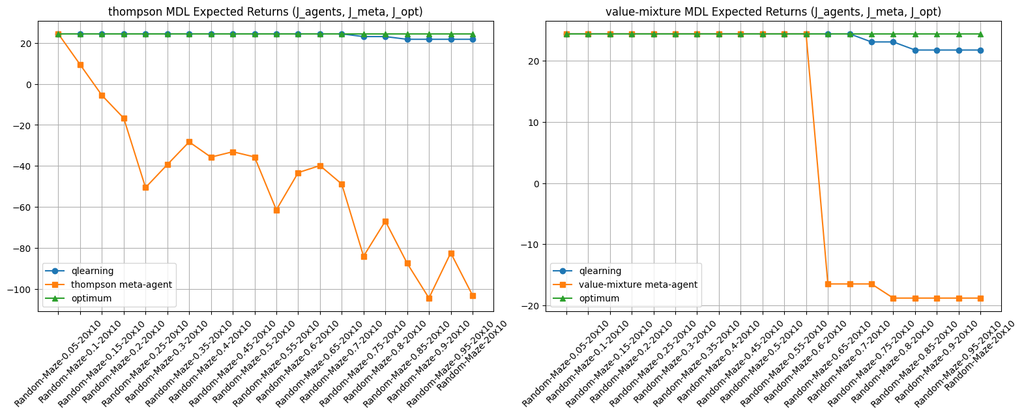

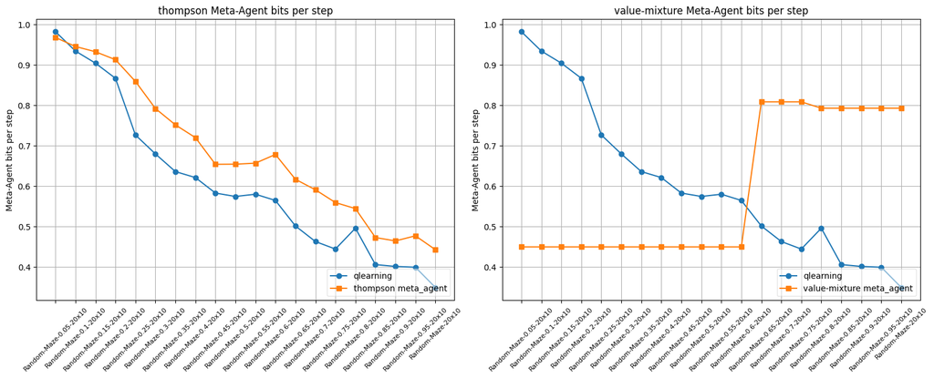

```
Thompson Belief trace
```

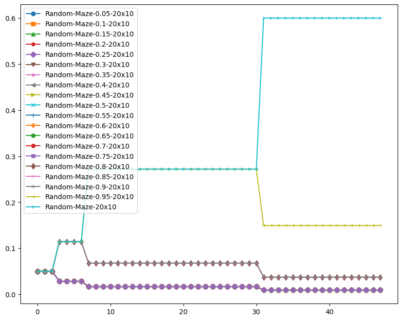

```
Value-Mixture Belief trace
```

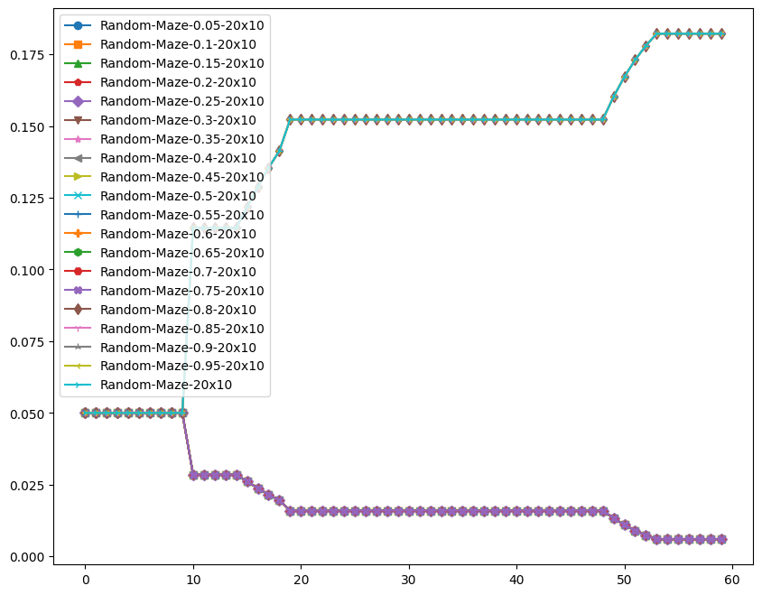

```python
if __name__ == "__main__":


    hspace=0.25
    wspace=0.15

    rows=1 + show_regret*1
    cols=len(all_modes)
    fig, axs = plt.subplots(rows, cols, figsize=(cols*6*(1+wspace*2), rows*5*(1+hspace)), constrained_layout=True)
    # fig.subplots_adjust(hspace=hspace, wspace=wspace)
    one_dim = cols == 1 or rows == 1

    row = -1
    for col, mode in enumerate(all_modes):

        plot_returns(mode_Opt_Reg_meta[mode], mode_Opt_Reg[mode], mode_Reg[mode], mode_J_meta[mode], mode_J_hat[mode], J_mix, post_J_mix, axs, row, col, one_dim, mode, envs_dic, show_regret=show_regret)

    plt.show()
    print()
    print()

    rows=1 + show_regret*1
    cols=len(all_modes)
    hspace=0.25
    wspace=0.15
    fig, axs = plt.subplots(rows, cols, figsize=(cols*6*(1+wspace*2), rows*5*(1+hspace)), constrained_layout=True)
    # fig.subplots_adjust(hspace=hspace, wspace=wspace)

    row=-1
    for col, mode in enumerate(all_modes):
        meta_agent_mode = mode

        plot_bits_per_step(mode_MDL_Regret_vals[mode], mode, greedy, envs, agents, axs, row, col, one_dim=(cols==1), legend_loc='lower right', show_global_mixture=False, show_regret=show_regret)

    plt.show()
    print()
    print('Thompson Belief trace')

    fig, ax = plt.subplots(figsize=(10,8))
    m = 0
    for env_name in ts_belief_df.columns:
        ax.plot(ts_belief_df.index, ts_belief_df[env_name], marker=plot_markers[m], label=env_name)
        m += 1
    ax.legend(loc='upper left')

    plt.show()
    print()
    print('Value-Mixture Belief trace')

    fig, ax = plt.subplots(figsize=(10,8))
    m = 0
    for env_name in vm_belief_df.columns:
        ax.plot(vm_belief_df.index, vm_belief_df[env_name], marker=plot_markers[m], label=env_name)
        m += 1
    ax.legend(loc='upper left')
```

```python
if __name__ == "__main__":


    all_data_dic = {}
    all_data_dic['mode_Opt_Reg_meta'] = mode_Opt_Reg_meta
    all_data_dic['mode_Opt_Reg'] = mode_Opt_Reg
    all_data_dic['mode_Reg'] = mode_Reg
    all_data_dic['mode_J_meta'] = mode_J_meta
    all_data_dic['mode_J_hat'] = mode_J_hat
    all_data_dic['J_mix'] = J_mix
    all_data_dic['post_J_mix'] = post_J_mix
    all_data_dic['mode_MDL_Regret_vals'] = mode_MDL_Regret_vals
    all_data_dic['ts_belief_df'] = ts_belief_df
    all_data_dic['vm_belief_df'] = vm_belief_df

    import pickle

    with open(f'{env_name} chart_data-N={N}.pkl', 'wb') as pkl_file:
        pickle.dump(dict(all_data_dic), pkl_file, protocol=pickle.HIGHEST_PROTOCOL) # Use highest protocol for best performance
```

```python
f'{env_name} chart_data-N={N}.pkl'
```

```
'Random-Maze-20x10 chart_data-N=20.pkl'
```